# Political leaning and use of public service media in a fragmented media landscape: longitudinal analysis over 30 years in Sweden

Peter M. Dahlgren

2018-02-21

# 1 Data preparation

## 1.1 Setup and import

```r
library(rio)
library(broom)
library(ggplot2)
library(RColorBrewer)
library(tidyverse)
theme_set(theme_minimal())
set.seed(1234)

# Läs in Super-SOM.
if(file.exists("supersom.RData"))
{
  print("Load RData")
  load("supersom.rdata")
} else {
  print("Import")
  system.time(supersom <- import("supersom/SND0905_SuperRSOM_v5.sav"))
  print("Saving RData")
  save.image(file="supersom.rdata")
}
```

```
## [1] "Load RData"
```

```r
# Recode rank variable into binary categorical factor.
dummy <- function(x, one=c(1, 2, 3, 4), zero=c(6, 7), labels=c("5 days/week or more", "More seldom"))
{
  newx <- NA
  newx[x %in% one]  <- 1
  newx[x %in% zero] <- 0
  newx <- factor(newx, levels=c(1, 0), labels=labels)
  return(newx)
}

# Calculate margin of error from proportion, and return confidence interval.
# p      = proportion (0-1)
# n      = total sample size
# z      = z score (defaults to 1.96 = 95 % confidence interval)
# digits = number of decimal places to be used (defaults to 2)
moe <- function(p, n, z=1.96, digits=2) {
  if(is.na(p)) {return("") }
  if(p > 1) { stop("p must be a proportion. For example, for 30 % use p = 0.30") }
  error <- z * (sqrt(p * (1 - p) / n)) * 100                                    # Calculate margin of error.
  conf.level <- round(100 - (pnorm(z, lower.tail=FALSE) * 2) * 100, 0)          # Convert z to confidence level (two-tailed).
  conf.lower <- p * 100 - error                                                 # Confidence interval lower bound.
  conf.upper <- p * 100 + error                                                 # Confidence interval upper bound.
  return(paste(round(p * 100, digits), " %, ",                                 # Nicely formatted message.
               conf.level, " % CI [", round(conf.lower, digits), ", ", round(conf.upper, digits), "]",
               " - margin of error: ±", round(error, digits),
               sep=""))
}
```

## 1.2 Recode variables

Recode Super-SOM 1986-2015.

In general:

- *5 days/week or more* is defined as at least 5 days per week.
- *More seldom* is defined as less than 5 days per week, including never.

```r
# Set election years to a binary variable.
supersom <- supersom %>% mutate(electionyear = case_when(year %in% c(1988, 1991, 1994, 1998, 2002, 2006, 2010, 2014) ~ 1, TRUE ~ 0))

# Demography.
supersom$age4a <- rio::factorize(supersom$age4a)
supersom$edu3 <- rio::factorize(supersom$edu3)
supersom$ideology <- supersom$ba10       # Self-reported political left/right placement 1-5.
supersom$ideology[supersom$ideology >= 98] <- NA
supersom$polinterest <- supersom$ca10 %>% recode("1"="4", "2"="3", "3"="2", "4"="1") %>% as.numeric()
supersom$polinterest <- factor(supersom$polinterest, levels=c(1, 2, 3, 4), labels=c("No political interest", "Low", "Medium", "High political interest"))
supersom$polinterest.num <- as.numeric(supersom$polinterest)   # Numeric 1-4 political interest.

# Public service.
supersom$svt1 <- supersom$jd20a             # SVT1
supersom$svt2 <- supersom$jd20b             # SVT2 (1992-2014)
supersom$svt1svt2 <- supersom$jd20c         # SVT1/SVT2 (2006-2013)
supersom$rapport <- supersom$jh10d          # SVT1 Rapport
supersom$aktuellt <- supersom$jh10c         # SVT2 Aktuellt
supersom$aktuelltrapport <- supersom$jh10e  # Aktuellt/Rapport
supersom$ekot <- supersom$jh10b             # SR Ekot

# Trust SVT.
supersom$trust.svt <- supersom$ka502a %>% recode("1"="3", "2"="3", "3"="2", "4"="1", "5"="1")
supersom$trust.svt <- factor(supersom$trust.svt, levels=c(3, 2, 1), labels=c("High trust", "Neither low nor high", "Low trust"))
supersom$trust.sr <- supersom$ka502e %>% recode("1"="3", "2"="3", "3"="2", "4"="1", "5"="1")
supersom$trust.sr <- factor(supersom$trust.sr, levels=c(3, 2, 1), labels=c("High trust", "Neither low nor high", "Low trust"))

# Trust SVT binary.
supersom$trust.svt.dich <- supersom$ka502a %>% recode("1"="1", "2"="1", "3"="999", "4"="0", "5"="0")
supersom$trust.svt.dich <- factor(supersom$trust.svt.dich, levels=c(1, 0), labels=c("High trust", "Low trust"))
supersom$trust.sr.dich <- supersom$ka502e %>% recode("1"="1", "2"="1", "3"="0", "4"="999", "5"="0")
supersom$trust.sr.dich <- factor(supersom$trust.sr.dich, levels=c(1, 0), labels=c("High trust", "Low trust"))

# Internet, social networking sites.
supersom$internet <- supersom$jb19        # Internet use last 12 months (1995-)
supersom$internetnews <- supersom$jb110c  # Internet news use (2005-)
supersom$sns <- supersom$jb110p           # Social media use, e.g. Facebook, Twitter (2009-)

# Recode into binary.
supersom$svt1.dich     <- dummy(supersom$svt1, one=c(2, 3), zero=c(4, 5, 6, 7))
supersom$svt2.dich     <- dummy(supersom$svt2, one=c(2, 3), zero=c(4, 5, 6, 7))
supersom$rapport.dich  <- dummy(supersom$rapport, one=c(1, 2), zero=c(3, 4, 5, 6))
supersom$aktuellt.dich <- dummy(supersom$aktuellt, one=c(1, 2), zero=c(3, 4, 5, 6))
supersom$ekot.dich     <- dummy(supersom$ekot, one=c(1, 2), zero=c(3, 4, 5, 6))
supersom$sns.dich      <- dummy(supersom$sns, one=c(7, 6), zero=c(5, 4, 3, 2, 1))
supersom$internet.dich <- dummy(supersom$internet, one=c(5), zero=c(4,3,2,1), labels=c("Use internet daily", "Use internet more seldom"))
supersom$internetnews.dich <- dummy(supersom$internetnews, one=c(7,6), zero=c(5,4,3,2,1))

# Combine Aktuellt/Rapport into single variable.
supersom$aktuelltrapport.dich[supersom$year %in% c(1984:2004)] <- ifelse(supersom$aktuellt[supersom$year %in% c(1984:2004)] <= 5 | supersom$rapport[supersom$year %in% c(1984:2004)] <= 5, 1, 0)
supersom$aktuelltrapport.dich[supersom$year %in% c(2005:2015)] <- ifelse(supersom$aktuelltrapport[supersom$year %in% c(2005:2015)] <= 5, 1, 0)

# Public service use: Using Rapport/Aktuellt/Ekot at least 5 days/week (or not).
supersom <- supersom %>%
  mutate(psuse = case_when(is.na(aktuelltrapport.dich) & is.na(ekot.dich) ~ 999,
                           aktuelltrapport.dich == 1                      ~ 1, # Aktuellt/Rapport
                           ekot.dich == 1                                 ~ 1, # Ekot
                           TRUE                                           ~ 0))
supersom$psuse <- factor(supersom$psuse, levels=c(1, 0), labels=c("PS news at least 5 days/week", "PS news more seldom"))

# Daily public service use: Using Rapport/Aktuellt/Ekot daily (or not).
supersom <- supersom %>%
  mutate(psuse.daily = case_when(jh10b == 1 ~ 1, # Ekot
                                 jh10c == 1 ~ 1, # Aktuellt
                                 jh10d == 1 ~ 1, # Rapport
                                 jh10e == 1 ~ 1, # Aktuellt/Rapport
                                 is.na(jh10b) & is.na(jh10c) & is.na(jh10d) & is.na(jh10e) ~ 999,
                                 TRUE       ~ 0))
supersom$psuse.daily <- factor(supersom$psuse.daily, levels=c(1, 0), labels=c("PS news daily", "PS news more seldom"))

supersom$aktuelltrapport.dich <- factor(supersom$aktuelltrapport.dich, levels=c(1, 0), labels=c("Daily/weekly", "Never/seldom"))

# Lef/right block.
supersom$partyblock[supersom$cb10 %in% c(1, 2)] <- 1     # Left: S+V
supersom$partyblock[supersom$cb10 %in% c(3, 4, 5, 6)] <- 2  # Right: C+L+M+KD
supersom$partyblock[supersom$partyblock > 2] <- NA
supersom$partyblock <- factor(supersom$partyblock, levels=1:2, labels=c("Left", "Right"), ordered=FALSE)
supersom$partyblock.num <- as.numeric(supersom$partyblock %>% recode("1"="-1", "2"="-1", "3"="1", "4"="1", "5"="1", "6"="1"))

# Party.
#supersom$party <- factor(supersom$cb10, levels=c(1:7, 10:13, 30), labels=c("Vänsterpartiet", "Socialdemokraterna", "Centerpartiet", "Liberalerna", "Moderaterna", "Kristdemokraterna", "Miljöpartiet", "Sverigedemokraterna", "Feministiskt initiativ", "Piratpartiet", "Ny demokrati", "Övriga"), ordered=FALSE)
supersom$party <- factor(supersom$cb10, levels=c(1:7, 10:13, 30), labels=c("Left Party (V)", "Social Democrats (S)", "Centre Party (C)", "Liberals (L)", "Moderate Party (M)", "Christian Democrats (KD)", "Green Party (MP)", "Sweden Democrats (SD)", "Feminist Initiative (FI)", "Pirate Party (PP)", "New Democracy (NyD)", "Other"), ordered=FALSE)
supersom$partysymbol <- factor(supersom$cb10, levels=c(1:7, 10:13, 30), labels=c("V", "S", "C", "L", "M", "KD", "MP", "SD", "FI", "PP", "NyD", "Other"), ordered=FALSE)

PartyColor <- unlist(list(V = "#DA291C",
                   S = "#E8112d",
                   C = "#009933",
                   L = "#006AB3",
                   M = "#52BDEC",
                   KD = "#000077",
                   MP = "#83CF39",
                   SD = "#DDDD00",
                   FI = "#CD1B68",
                   PP = "#572B85",
                   NyD = "#572B85",
                   Other = "#CCCCCC"), use.names=FALSE)

# Ideological extremism (center = 0, toward left/right = 2)
supersom$polextreme <- supersom$ideology %>% recode("1"="2", "2"="1", "3"="0", "4"="1", "5"="2") %>% as.numeric()

# Strong supporter of party?
supersom$partystrength <- supersom$cb20 %>% recode("1"="2", "2"="1", "3"="0")
supersom$partystrength <- factor(supersom$partystrength, levels=c(0,1,2), labels=c("No party supporter", "Weak party supporter", "Strong party supporter"), ordered=FALSE)

# Political leaning: left/center/right.
supersom$leaning <- supersom$ideology %>% recode("1"="1", "2"="1", "3"="2", "4"="3", "5"="3")
supersom$leaning <- factor(supersom$leaning, levels=c(1,2,3), labels=c("Left", "Center", "Right"), ordered=FALSE)
supersom$leaning.num <- as.numeric(supersom$ideology %>% recode("1"="-2", "2"="-1", "3"="0", "4"="1", "5"="2"))

# Factor sex.
supersom$sex <- factor(supersom$sex, levels=c(1, 2), labels=c("Female", "Male"), ordered=FALSE)

# Convert year to date yyyy-mm-dd.
supersom$date <- as.Date(paste(supersom$year, "-01-01", sep=""))
```

## 1.3 Create public pervice (PS) index

Create a additive public service index, with the use of Rapport/Aktuellt/Ekot which is then averaged.

Continous scale ranging from 1 (never) to 6 (daily).

```r
# First, combine Aktuellt & Rapport (1986-2005). Use the highest frequency from either variable. In other words, if respondent use either Aktuellt or Rapport daily, then the value is daily.
# (Cumbersome coding because bug in case_when, see https://github.com/tidyverse/dplyr/issues/2927)
supersom$aktuelltrapport_early[supersom$aktuellt == 6 | supersom$aktuellt == 6] <- 6
supersom$aktuelltrapport_early[supersom$aktuellt == 5 | supersom$aktuellt == 5] <- 5
supersom$aktuelltrapport_early[supersom$aktuellt == 4 | supersom$aktuellt == 4] <- 4
supersom$aktuelltrapport_early[supersom$aktuellt == 3 | supersom$aktuellt == 3] <- 3
supersom$aktuelltrapport_early[supersom$aktuellt == 2 | supersom$aktuellt == 2] <- 2
supersom$aktuelltrapport_early[supersom$aktuellt == 1 | supersom$aktuellt == 1] <- 1

# Add to variable 1986-2004.
supersom$aktuelltrapport.combined[supersom$year <= 2004] <- supersom$aktuelltrapport_early[supersom$year <= 2004]

# Use the Aktuellt/Rapport measure from 2005 an onwards.
supersom$aktuelltrapport.combined[supersom$year >= 2005] <- supersom$jh10e[supersom$year >= 2005]

# Add values (Aktuellt and Rapport + Ekot) and divide by 2, thus creating a continous interval scale, from 1-6.
supersom$psindex <- (supersom$aktuelltrapport.combined + supersom$ekot) / 2

# Reverse code index, so that 6=daily, 1=never.
supersom$psindex.rev <- min(supersom$psindex, na.rm=TRUE) + max(supersom$psindex, na.rm=TRUE) - supersom$psindex

library(sjlabelled)
```

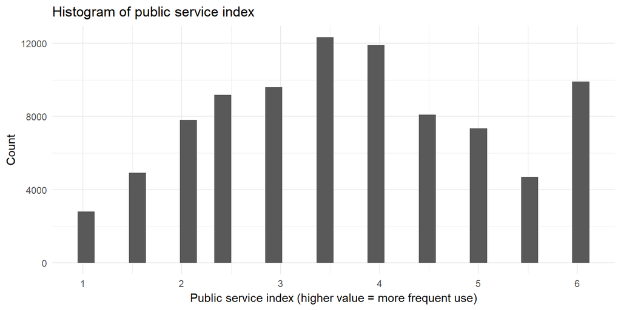

```r
set_label(supersom$psindex.rev, "label") <- "Public service index"

# Histogram of index.
ggplot(supersom, aes(psindex.rev)) +
  geom_histogram() +
  scale_x_continuous(breaks=seq(0, 6, 1)) +
  labs(title="Histogram of public service index",
       y="Count",
       x="Public service index (higher value = more frequent use)")
```

```r
library(moments)
sum(table(supersom$psindex.rev))
```

```
## [1] 88617
```

```r
mean(supersom$psindex.rev, na.rm=TRUE)
```

```
## [1] 3.687983
```

```r
sd(supersom$psindex.rev, na.rm=TRUE)
```

```
## [1] 1.391549
```

```r
skewness(supersom$psindex.rev, na.rm=TRUE)
```

```
## [1] 0.03896865
```

```r
kurtosis(supersom$psindex.rev, na.rm=TRUE)
```

```
## [1] 2.114573
```

# 2 Public service (PS) use

## 2.1 Political preferences and PS use correlations

```r
corr1 <- cor.test(supersom$polextreme, supersom$polinterest.num)
corr2 <- cor.test(as.numeric(supersom$partystrength), supersom$polinterest.num)
corr3 <- cor.test(supersom$leaning.num, supersom$psindex.rev, na.action="pairwise.complete.obs")
```

Correlation between political extremity (left or right) and political interest: r(97193) = 0.2548581, p=0.

Correlation between party strength and political interest: r(92937) = 0.2322776, p=0.

Correlation between leaning (left to right, -2 to -2) and public service news index:r(86049) = 0.012235, p=3.317486810^{-4}.

## 2.2 Frequency of PS use

Use any of Aktuellt, Rapport or Ekot.

Frequency table of public service news use.

```r
supersom %>%
  select(year, psuse) %>%
  group_by(year, psuse) %>%
  na.exclude() %>%
  count() %>%
  spread(psuse, n)
```

```
## # A tibble: 30 x 3
## # Groups:   year [30]
##     year `PS news at least 5 days/week` `PS news more seldom`
##  * <dbl>                          <int>                 <int>
##  1  1986                           1594                    21
##  2  1987                           1636                    13
##  3  1988                           1613                    16
##  4  1989                           1545                    16
##  5  1990                           1547                    16
##  6  1991                           1539                    20
##  7  1992                           1835                    22
##  8  1993                           1777                    39
##  9  1994                           1628                    36
## 10  1995                           1699                    42
## # ... with 20 more rows
```

## 2.3 PS and leaning

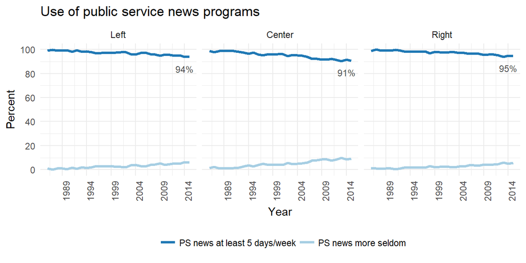

```r
df <- supersom %>%
  select(date, psuse, leaning) %>%
  na.exclude() %>%
  group_by(leaning, date, psuse) %>%
  summarize(n = n()) %>%
  mutate(percent = n / sum(n) * 100)

df %>%
  ggplot(aes(date, percent, color=factor(psuse))) +
    geom_line(size=1.2) +
    #geom_smooth(method="lm") +
    #geom_text(aes(label=round(percent), alpha=0.7), nudge_y=-6, size=2) +
    scale_color_manual(values = sort(brewer.pal(3, "Paired")), name=NULL) +
    scale_y_continuous(labels=scales::comma, limit=c(0, 100), breaks=seq(0, 100, 20)) +
    scale_x_date(date_label="%Y", date_breaks="5 year") +
    geom_text(data=subset(df, (date==max(date)) & psuse == "PS news at least 5 days/week"), aes(label=paste0(round(percent), "%")), color="black", alpha=0.7, nudge_x=-365, nudge_y=-10, size=3) +
    theme(legend.position = "bottom", axis.text.x = element_text(angle=90)) +
    labs(title="Use of public service news programs",
         subtitle=NULL,
         x="Year",
         y="Percent") +
    facet_wrap(~ leaning)
```

```r
print(paste("n =", sum(df$n)))
```

```
## [1] "n = 95462"
```

For the latest year, is the difference statistically significant between the left and right?

```r
left <- supersom %>% filter(year == max(year) & leaning == "Left") %>% select(psuse) %>% na.exclude()
center <- supersom %>% filter(year == max(year) & leaning == "Center") %>% select(psuse) %>% na.exclude()
right <- supersom %>% filter(year == max(year) & leaning == "Right") %>% select(psuse) %>% na.exclude()

t.test(x=as.numeric(center$psuse), y=as.numeric(left$psuse), alternative=c("two.sided"), conf.level=0.95)
```

```
##
##  Welch Two Sample t-test
##
## data:  as.numeric(center$psuse) and as.numeric(left$psuse)
## t = 4.0702, df = 4216.9, p-value = 4.784e-05
## alternative hypothesis: true difference in means is not equal to 0
## 95 percent confidence interval:
##  0.01665289 0.04760469
## sample estimates:
## mean of x mean of y
##  1.092959  1.060830
```

```r
t.test(x=as.numeric(center$psuse), y=as.numeric(right$psuse), alternative=c("two.sided"), conf.level=0.95)
```

```
##
##  Welch Two Sample t-test
##
## data:  as.numeric(center$psuse) and as.numeric(right$psuse)
## t = 5.1399, df = 3946.9, p-value = 2.882e-07
## alternative hypothesis: true difference in means is not equal to 0
## 95 percent confidence interval:
##  0.02374627 0.05303310
## sample estimates:
## mean of x mean of y
##  1.092959  1.054569
```

```r
t.test(x=as.numeric(left$psuse), y=as.numeric(right$psuse), alternative=c("two.sided"), conf.level=0.95)
```

```
##
##  Welch Two Sample t-test
##
## data:  as.numeric(left$psuse) and as.numeric(right$psuse)
## t = 0.98434, df = 5090.1, p-value = 0.325
## alternative hypothesis: true difference in means is not equal to 0
## 95 percent confidence interval:
##  -0.006208472  0.018730249
## sample estimates:
## mean of x mean of y
##  1.060830  1.054569
```

What is the percentage of people who use public service news, grouped by leaning?

```r
df <- supersom %>%
  select(date, psuse, leaning) %>%
  na.exclude() %>%
  group_by(leaning, date, psuse) %>%
  summarize(n = n()) %>%
  spread(psuse, n) %>%
  setNames(c("leaning", "date", "n.often", "n.seldom")) %>%
  mutate(n = n.often + n.seldom) %>%
  mutate(percent.often = (n.often / n) * 100)

df$apa <- mapply(moe, df$percent.often / 100, df$n, digits=0)

df %>% filter(date %in% c(as.Date("1986-01-01"), as.Date("2015-01-01")))
```

```
## # A tibble: 6 x 7
## # Groups:   leaning, date [6]
##   leaning date       n.often n.seldom     n percent.often apa
##   <fct>   <date>       <int>    <int> <int>         <dbl> <chr>
## 1 Left    1986-01-01     520        5   525          99.0 99 %, 95 % CI [~
## 2 Left    2015-01-01    2285      148  2433          93.9 94 %, 95 % CI [~
## 3 Center  1986-01-01     512        7   519          98.7 99 %, 95 % CI [~
## 4 Center  2015-01-01    1971      202  2173          90.7 91 %, 95 % CI [~
## 5 Right   1986-01-01     500        7   507          98.6 99 %, 95 % CI [~
## 6 Right   2015-01-01    2876      166  3042          94.5 95 %, 95 % CI [~
```

## 2.4 PS and political interest

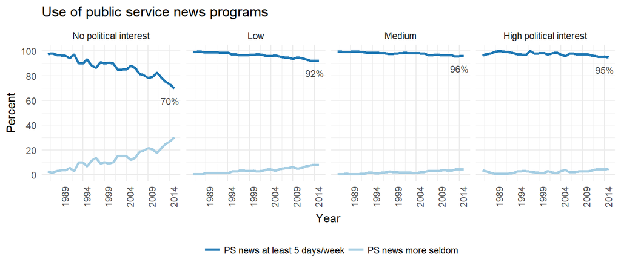

```r
df <- supersom %>%
  select(date, psuse, polinterest) %>%
  na.exclude() %>%
  group_by(polinterest, date, psuse) %>%
  summarize(n = n()) %>%
  mutate(percent = n / sum(n) * 100)

df %>%
  ggplot(aes(date, percent, color=factor(psuse))) +
    geom_line(size=1.2) +
    scale_color_manual(values = sort(brewer.pal(3, "Paired")), name=NULL) +
    scale_y_continuous(labels=scales::comma, limit=c(0, 100), breaks=seq(0, 100, 20)) +
    scale_x_date(date_label="%Y", date_breaks="5 year") +
    geom_text(data=subset(df, (date==max(date)) & psuse == "PS news at least 5 days/week"), aes(label=paste0(round(percent), "%")), color="black", alpha=0.7, nudge_x=-365, nudge_y=-10, size=3) +
    theme(legend.position = "bottom", axis.text.x = element_text(angle=90)) +
    labs(title="Use of public service news programs",
         subtitle=NULL,
         x="Year",
         y="Percent") +
    facet_grid(~ polinterest)
```

```r
print(paste("n =", sum(df$n)))
```

```
## [1] "n = 97257"
```

What is the percentage of people who use public service news, grouped by political interest?

```r
df <- supersom %>%
  select(date, psuse, polinterest) %>%
  na.exclude() %>%
  group_by(polinterest, date, psuse) %>%
  summarize(n = n()) %>%
  spread(psuse, n) %>%
  setNames(c("polinterest", "date", "n.often", "n.seldom")) %>%
  mutate(n = n.often + n.seldom) %>%
  mutate(percent.often = (n.often / n) * 100)

df$apa <- mapply(moe, df$percent.often / 100, df$n, digits=0)

df %>% filter(date %in% c(as.Date("1986-01-01"), as.Date("2015-01-01")))
```

```
## # A tibble: 8 x 7
## # Groups:   polinterest, date [8]
##   polinterest   date       n.often n.seldom     n percent.often apa
##   <fct>         <date>       <int>    <int> <int>         <dbl> <chr>
## 1 No political~ 1986-01-01     145        4   149          97.3 97 %, 95 ~
## 2 No political~ 2015-01-01     288      125   413          69.7 70 %, 95 ~
## 3 Low           1986-01-01     700        6   706          99.2 99 %, 95 ~
## 4 Low           2015-01-01    2139      185  2324          92.0 92 %, 95 ~
## 5 Medium        1986-01-01     599        4   603          99.3 99 %, 95 ~
## 6 Medium        2015-01-01    3565      158  3723          95.8 96 %, 95 ~
## 7 High politic~ 1986-01-01     138        5   143          96.5 97 %, 95 ~
## 8 High politic~ 2015-01-01    1231       66  1297          94.9 95 %, 95 ~
```

## 2.5 PS and extremity

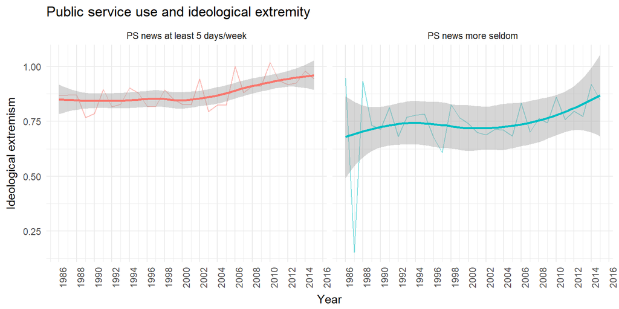

```r
supersom %>%
  select(date, psuse, polextreme) %>%
  na.exclude() %>%
  group_by(psuse, date) %>%
  summarize(meanextremism = mean(polextreme, na.rm=TRUE)) %>%
  ggplot(aes(date, meanextremism, color=psuse)) +
    geom_line(alpha=0.5) +
    geom_smooth(method="loess") +
    scale_y_continuous(labels=scales::comma) +
    scale_x_date(date_label="%Y", date_breaks="2 year") +
    theme(legend.position = "none", axis.text.x = element_text(angle=90)) +
    labs(title="Public service use and ideological extremity",
         x="Year",
         y="Ideological extremism") +
    facet_grid(~ psuse)
```

```r
print(paste("n =", supersom %>%
  select(date, psuse, polextreme) %>%
  na.exclude() %>% count()))
```

```
## [1] "n = 95462"
```

## 2.6 PS and party support

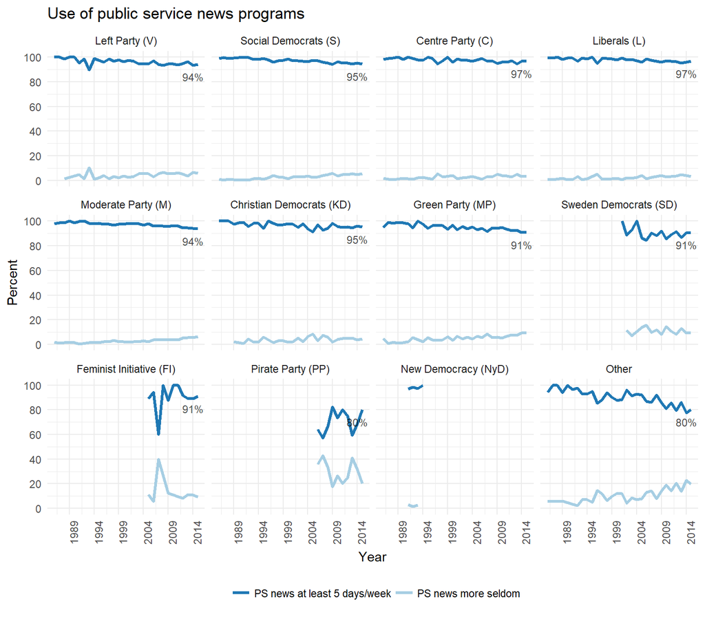

```r
df <- supersom %>%
  select(date, psuse, party) %>%
  na.exclude() %>%
  group_by(party, date, psuse) %>%
  summarize(n = n()) %>%
  mutate(percent = n / sum(n) * 100)
  #filter(!party %in% c("Feministiskt initiativ", "Piratpartiet", "Ny demokrati", "Övriga")) %>%

df %>%
  ggplot(aes(date, percent, color=factor(psuse))) +
  geom_line(size=1.2) +
  #geom_smooth(method="lm") +
  scale_color_manual(values = sort(brewer.pal(3, "Paired")), name=NULL) +
  scale_y_continuous(labels=scales::comma, limit=c(0, 100), breaks=seq(0, 100, 20)) +
  scale_x_date(date_label="%Y", date_breaks="5 year") +
  geom_text(data=subset(df, (date==max(date)) & psuse == "PS news at least 5 days/week"), aes(label=paste0(round(percent), "%")), color="black", alpha=0.7, nudge_x=-365, nudge_y=-10, size=3) +
  theme(legend.position = "bottom", axis.text.x = element_text(angle=90)) +
  labs(title="Use of public service news programs", subtitle=NULL, x="Year", y="Percent", alpha=NULL, label=NULL) +
  facet_wrap(~ party, ncol = 4)
```

```r
print(paste("n =", sum(df$n)))
```

```
## [1] "n = 89929"
```

## 2.7 PS and party strength

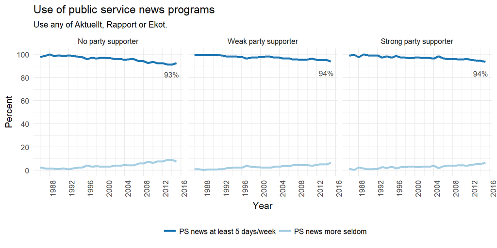

```r
df <- supersom %>%
  select(date, psuse, partystrength) %>%
  na.exclude() %>%
  group_by(partystrength, date, psuse) %>%
  summarize(n = n()) %>%
  mutate(percent = n / sum(n) * 100)

df %>%
  ggplot(aes(date, percent, color=factor(psuse))) +
    geom_line(size=1.2) +
    #geom_smooth(method="lm") +
    scale_color_manual(values = sort(brewer.pal(3, "Paired")), name=NULL) +
    scale_y_continuous(labels=scales::comma, limit=c(0, 100), breaks=seq(0, 100, 20)) +
    scale_x_date(date_label="%Y", date_breaks="4 year") +
    geom_text(data=subset(df, (date==max(date)) & psuse == "PS news at least 5 days/week"), aes(label=paste0(round(percent), "%")), color="black", alpha=0.7, nudge_x=-365, nudge_y=-10, size=3) +
    theme(legend.position = "bottom", axis.text.x = element_text(angle=90)) +
    labs(title="Use of public service news programs",
         subtitle="Use any of Aktuellt, Rapport or Ekot.",
         x="Year",
         y="Percent") +
    facet_wrap(~ partystrength)
```

```r
print(paste("n =", sum(df$n)))
```

```
## [1] "n = 91375"
```

What is the percentage of people who use public service news, grouped by party?

```r
df <- supersom %>%
  select(date, psuse, party) %>%
  na.exclude() %>%
  group_by(party, date, psuse) %>%
  summarize(n = n()) %>%
  spread(psuse, n) %>%
  setNames(c("party", "date", "n.often", "n.seldom")) %>%
  mutate(n = n.often + n.seldom) %>%
  mutate(percent.often = (n.often / n) * 100)

df$apa <- mapply(moe, df$percent.often / 100, df$n, digits=0)

#df %>% filter(date %in% c(as.Date("1986-01-01"), as.Date("2015-01-01")))
df
```

```
## # A tibble: 280 x 7
## # Groups:   party, date [280]
##    party          date       n.often n.seldom     n percent.often apa
##    <fct>          <date>       <int>    <int> <int>         <dbl> <chr>
##  1 Left Party (V) 1986-01-01      47       NA    NA          NA   ""
##  2 Left Party (V) 1987-01-01      41       NA    NA          NA   ""
##  3 Left Party (V) 1988-01-01      66        1    67          98.5 99 %, 9~
##  4 Left Party (V) 1989-01-01     102       NA    NA          NA   ""
##  5 Left Party (V) 1990-01-01      96       NA    NA          NA   ""
##  6 Left Party (V) 1991-01-01      61        3    64          95.3 95 %, 9~
##  7 Left Party (V) 1992-01-01      65        1    66          98.5 98 %, 9~
##  8 Left Party (V) 1993-01-01      44        5    49          89.8 90 %, 9~
##  9 Left Party (V) 1994-01-01     110        1   111          99.1 99 %, 9~
## 10 Left Party (V) 1995-01-01     209        5   214          97.7 98 %, 9~
## # ... with 270 more rows
```

```r
df <- supersom %>%
  select(partystrength, psuse) %>%
  na.exclude() %>%
  mutate(partystrength = as.numeric(partystrength), psuse=as.numeric(psuse))

corr <- cor.test(df$partystrength, df$psuse)
```

Correlation between public service news use and party identification/support: r(91373) = -0.0367499, p=1.091096210^{-28}.

# 3 Univariate statistics

## 3.1 Respondents

### 3.1.1 Sample size

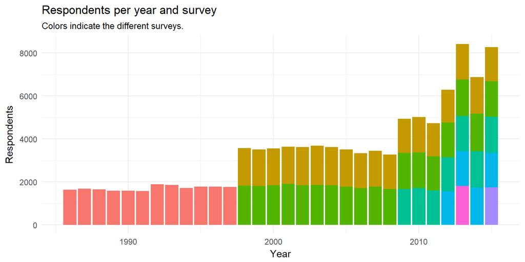

```r
supersom %>%
  ggplot(aes(year)) +
  geom_bar(position="stack", aes(fill=factor(formular))) +
  theme(legend.position = "none") +
  labs(title="Respondents per year and survey",
       subtitle="Colors indicate the different surveys.",
       x="Year",
       y="Respondents")
```

Sample size statistics.

```r
# Sample size min, max, mean.
supersom %>% group_by(year) %>% summarize(n = NROW(year)) %>% select(n) %>% unlist() %>% summary()
```

```
##    Min. 1st Qu.  Median    Mean 3rd Qu.    Max.
##    1573    1760    3467    3453    3666    8406
```

```r
# Sample size std dev.
supersom %>% group_by(year) %>% summarize(n = NROW(year)) %>% select(n) %>% unlist() %>% sd()
```

```
## [1] 1953.831
```

```r
# Total n.
print(paste("Total n =", nrow(supersom)))
```

```
## [1] "Total n = 103589"
```

### 3.1.2 Response rate

Data from page 542 table 5: http://som.gu.se/digitalAssets/1487/1487725_531-560-frida-vernersdotter--metod.pdf

```r
surveys <- data.frame(
  year=1986:2015,
  date=as.Date(seq.Date(as.Date("1986-01-01"), as.Date("2015-01-01"), by = "year")),
  responserate=c(65,67,66,63,63,63,67,66,61,63,63,63,64,63,59,61,60,61,60,58,55,57,54,55,56,52,52,49,51,51)
)

print(paste("Response rate M =", mean(surveys$responserate)))
```

```
## [1] "Response rate M = 59.6"
```

```r
print(paste("Response rate SD =", sd(surveys$responserate)))
```

```
## [1] "Response rate SD = 5.24963052887107"
```

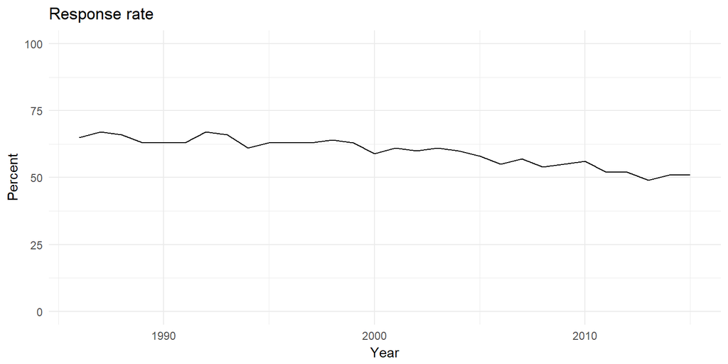

```r
surveys %>% ggplot(aes(date, responserate)) +
  geom_line() +
  scale_y_continuous(limits = c(0, 100)) +
  labs(title="Response rate", x="Year", y="Percent")
```

## 3.2 Demography

Descriptive statistics.

```r
# Respondents descriptive.
supersom %>% group_by(year) %>% summarize(respondents = n()) %>% print(n = nrow(.))
```

```
## # A tibble: 30 x 2
##     year respondents
##    <dbl>       <int>
##  1  1986        1624
##  2  1987        1671
##  3  1988        1643
##  4  1989        1578
##  5  1990        1582
##  6  1991        1573
##  7  1992        1889
##  8  1993        1857
##  9  1994        1704
## 10  1995        1777
## 11  1996        1779
## 12  1997        1754
```

[output cut: 18 more lines]

```r
# % education.
round(prop.table(table(rio::factorize(supersom$edu3))) * 100, 0)
```

```
##
##                   Låg (max grundskola eller motsvarande)
##                                                       24
## Medel (allt över grundskola men ej högskola/universitet)
##                                                       44
##           Hög (studier/examen från högskola/universitet)
##                                                       32
##                                         Frågan ej ställd
##                                                        0
##                                                  Ej svar
##                                                        0
```

```r
# % age.
round(prop.table(table(rio::factorize(supersom$age4a))) * 100, 0)
```

```
##
##        16-29 år        30-49 år        50-64 år            65--
##              18              32              26              23
## Ej svar/uppgift
##               0
```

```r
# % sex.
round(prop.table(table(rio::factorize(supersom$sex))) * 100, 0)
```

```
##
## Female   Male
##     52     48
```

```r
# Age, political interest, political leaning
supersom %>% select(age, polinterest, leaning) %>% tidy()
```

```
##         column      n      mean         sd median   trimmed     mad min
## 1          age 101663 48.512605 18.1446076     49 48.602648 22.2390  15
## 2 polinterest* 100126  2.589717  0.8002844      3  2.587501  1.4826   1
## 3     leaning*  98155  2.019174  0.8271697      2  2.023967  1.4826   1
##   max range        skew   kurtosis          se
## 1  85    70 -0.04716512 -1.0131801 0.056907056
## 2   4     3 -0.06749927 -0.4641424 0.002529129
## 3   3     2 -0.03567317 -1.5376058 0.002640209
```

### 3.2.1 Age

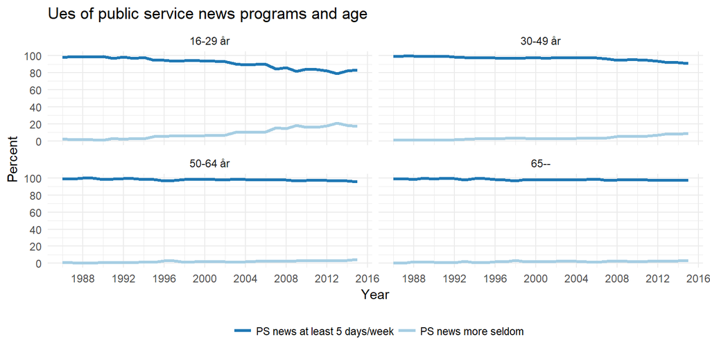

```r
supersom %>%
  select(date, psuse, age4a) %>%
  na.exclude() %>%
  group_by(age4a, date, psuse) %>%
  summarize(n = n()) %>%
  mutate(percent = n / sum(n) * 100) %>%
  ggplot(aes(date, percent, color=factor(psuse))) +
    geom_line(size=1.2) +
    #geom_smooth(method="lm") +
    scale_color_manual(values = sort(brewer.pal(3, "Paired")), name=NULL) +
    scale_y_continuous(labels=scales::comma, limit=c(0, 100), breaks=seq(0, 100, 20)) +
    scale_x_date(date_label="%Y", date_breaks="4 year") +
    theme(legend.position = "bottom", axis.text.x = element_text(angle=0)) +
    labs(title="Ues of public service news programs and age",
         subtitle=NULL,
         x="Year",
         y="Percent") +
    facet_wrap(~ age4a)
```

```r
print(paste("n =", supersom %>%
  select(date, psuse, age8a) %>%
  na.exclude() %>% count()))
```

```
## [1] "n = 97830"
```

### 3.2.2 Sex

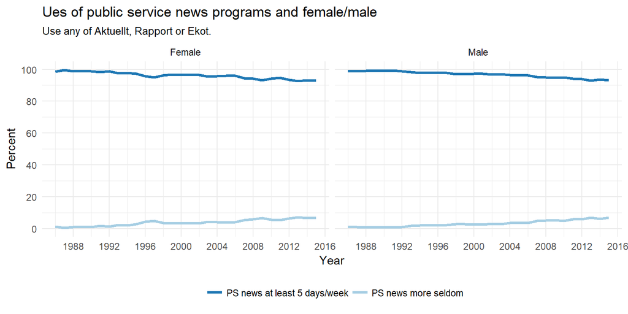

```r
supersom %>%
  select(date, psuse, sex) %>%
  na.exclude() %>%
  filter(as.numeric(sex) < 3) %>%
  group_by(sex, date, psuse) %>%
  summarize(n = n()) %>%
  mutate(percent = n / sum(n) * 100) %>%
  ggplot(aes(date, percent, color=factor(psuse))) +
    geom_line(size=1.2) +
    #geom_smooth(method="lm") +
    scale_color_manual(values = sort(brewer.pal(3, "Paired")), name=NULL) +
    scale_y_continuous(labels=scales::comma, limit=c(0, 100), breaks=seq(0, 100, 20)) +
    scale_x_date(date_label="%Y", date_breaks="4 year") +
    theme(legend.position = "bottom", axis.text.x = element_text(angle=0)) +
    labs(title="Ues of public service news programs and female/male",
         subtitle="Use any of Aktuellt, Rapport or Ekot.",
         x="Year",
         y="Percent") +
    facet_wrap(~ sex)
```

```r
print(paste("n =", supersom %>%
  select(date, psuse, sex) %>%
  na.exclude() %>% count()))
```

```
## [1] "n = 98565"
```

### 3.2.3 Education

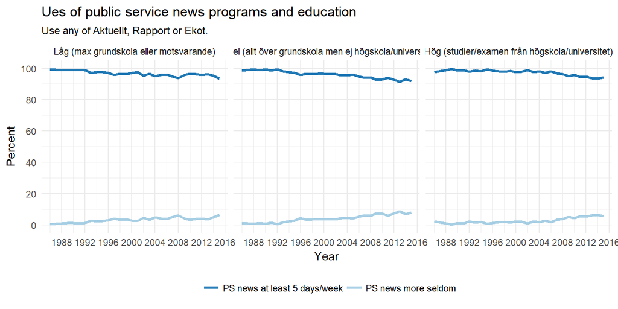

```r
supersom %>%
  select(date, psuse, edu3) %>%
  na.exclude() %>%
  group_by(edu3, date, psuse) %>%
  summarize(n = n()) %>%
  mutate(percent = n / sum(n) * 100) %>%
  ggplot(aes(date, percent, color=factor(psuse))) +
    geom_line(size=1.2) +
    #geom_smooth(method="lm") +
    scale_color_manual(values = sort(brewer.pal(3, "Paired")), name=NULL) +
    scale_y_continuous(labels=scales::comma, limit=c(0, 100), breaks=seq(0, 100, 20)) +
    scale_x_date(date_label="%Y", date_breaks="4 year") +
    theme(legend.position = "bottom", axis.text.x = element_text(angle=0)) +
    labs(title="Ues of public service news programs and education",
         subtitle="Use any of Aktuellt, Rapport or Ekot.",
         x="Year",
         y="Percent") +
    facet_wrap(~ edu3)
```

```r
print(paste("n =", supersom %>%
  select(date, psuse, edu3) %>%
  na.exclude() %>% count()))
```

```
## [1] "n = 94621"
```

### 3.2.4 Social class

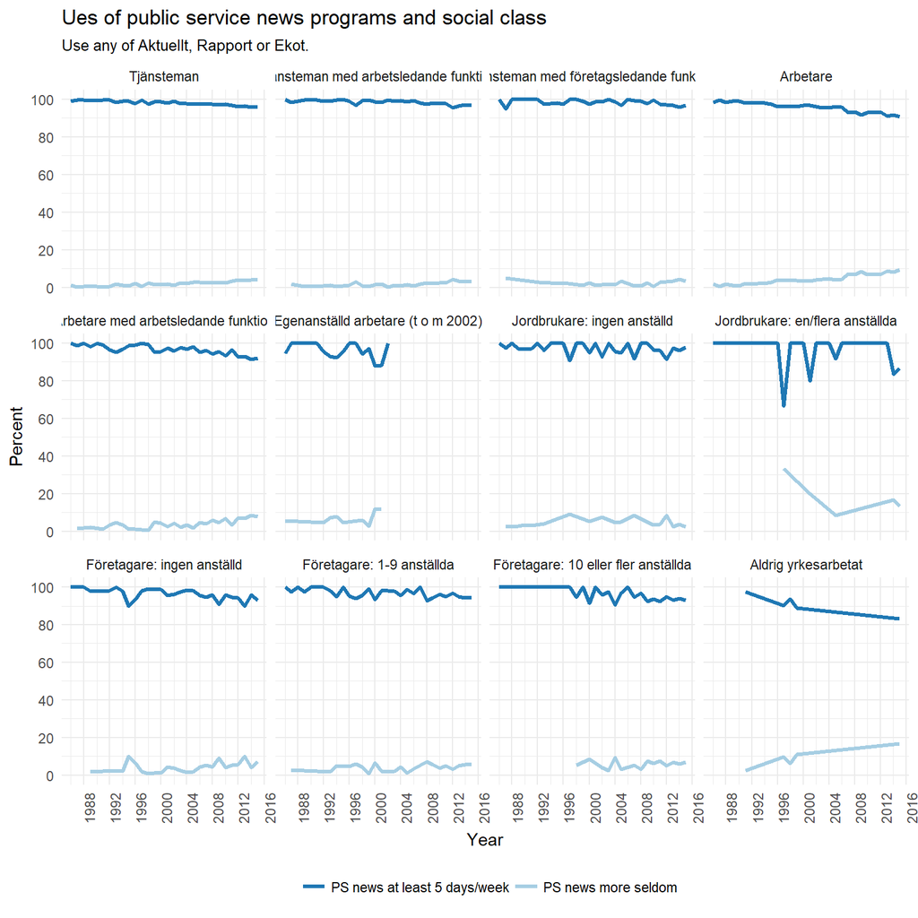

```r
supersom$occgr <- rio::factorize(supersom$occgr)
supersom %>%
  select(date, psuse, occgr) %>%
  na.exclude() %>%
  group_by(occgr, date, psuse) %>%
  summarize(n = n()) %>%
  mutate(percent = n / sum(n) * 100) %>%
  ggplot(aes(date, percent, color=factor(psuse))) +
    geom_line(size=1.2) +
    #geom_smooth(method="lm") +
    scale_color_manual(values = sort(brewer.pal(3, "Paired")), name=NULL) +
    scale_y_continuous(labels=scales::comma, limit=c(0, 100), breaks=seq(0, 100, 20)) +
    scale_x_date(date_label="%Y", date_breaks="4 year") +
    theme(legend.position = "bottom", axis.text.x = element_text(angle=90)) +
    labs(title="Ues of public service news programs and social class",
         subtitle="Use any of Aktuellt, Rapport or Ekot.",
         x="Year",
         y="Percent") +
    facet_wrap(~ occgr)
```

```r
print(paste("n =", supersom %>%
  select(date, psuse, occgr) %>%
  na.exclude() %>% count()))
```

```
## [1] "n = 85508"
```

## 3.3 Political preferences

Demography, summary statistics, number of respondents etc.

### 3.3.1 Political interest

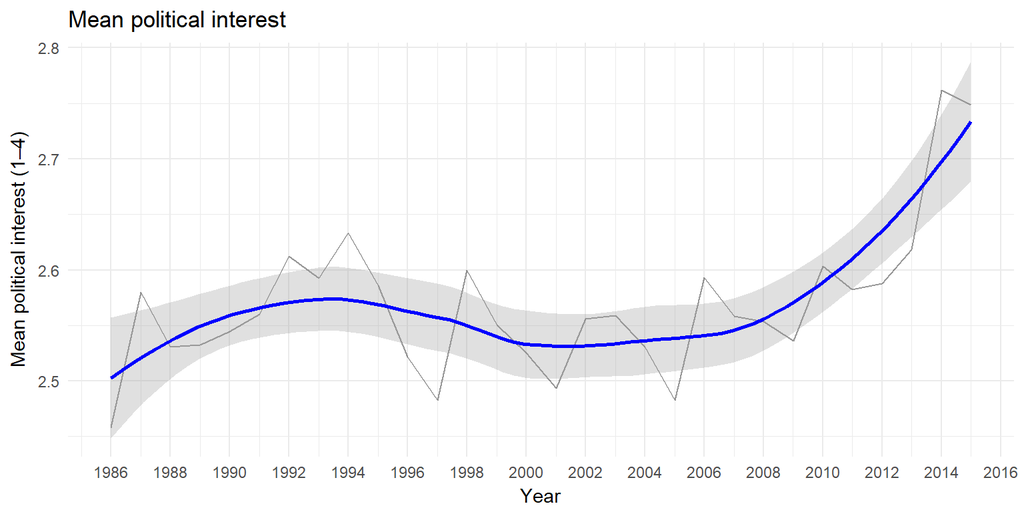

```r
supersom %>%
  group_by(date) %>%
  select(date, polinterest.num) %>%
  summarize(meaninterest=mean(polinterest.num, na.rm=TRUE)) %>%
  ggplot(aes(date, meaninterest)) +
  geom_line(alpha=0.4) +
  geom_smooth(method = "loess", level=0.95, color="blue", alpha=0.3) +
  scale_y_continuous(labels=scales::comma) +
  scale_x_date(date_label="%Y", date_breaks="2 year") +
  #geom_vline(xintercept = as.numeric(as.Date("2004-01-01")), color="black", alpha=0.9, linetype=2) +
  #geom_vline(xintercept = as.numeric(as.Date("2006-01-01")), color="black", alpha=0.9, linetype=4)
  #annotate("text", x=as.Date("2008-06-01"), y=2.35, label="Facebook launches 2004") +
    labs(title="Mean political interest",
       #subtitle="Loess smoothing with 95 % CI.",
       x="Year",
       y="Mean political interest (1–4)")
```

```r
print(paste("n =", supersom %>%
              select(date, polinterest.num) %>%
              na.exclude() %>% count()))
```

```
## [1] "n = 100126"
```

Political interest by leaning.

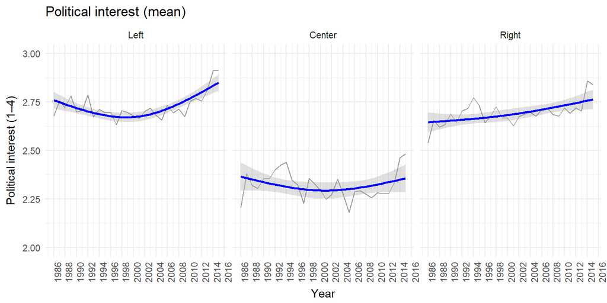

```r
supersom %>%
  group_by(leaning, date) %>%
  select(date, polinterest.num, leaning) %>%
  na.exclude() %>%
  summarize(meaninterest=mean(polinterest.num, na.rm=TRUE)) %>%
  ggplot(aes(date, meaninterest)) +
  geom_line(alpha=0.4) +
  #geom_smooth(method = "loess", level=0.95, color="blue", alpha=0.3) +
  #geom_smooth(method = "lm", level=0.95, color="blue", alpha=0.3) +
  geom_smooth(method = "lm", formula=y ~ splines::ns(x, df=2), level=0.95, color="blue", alpha=0.3) +
  scale_y_continuous(labels=scales::comma, limits = c(2, 3)) +
  scale_x_date(date_label="%Y", date_breaks="2 year") +
  theme(axis.text.x = element_text(angle=90)) +
  labs(title="Political interest (mean)",
       subtitle=NULL,
       x="Year",
       y="Political interest (1–4)") +
  #geom_vline(xintercept = as.numeric(as.Date("2004-01-01")), color="black", alpha=0.9, linetype=2) +
  #geom_vline(xintercept = as.numeric(as.Date("2006-01-01")), color="black", alpha=0.9, linetype=4)
  #annotate("text", x=as.Date("2008-06-01"), y=2.35, label="Facebook launches 2004") +
  facet_wrap(~ leaning)
```

Political interest as percent instead.

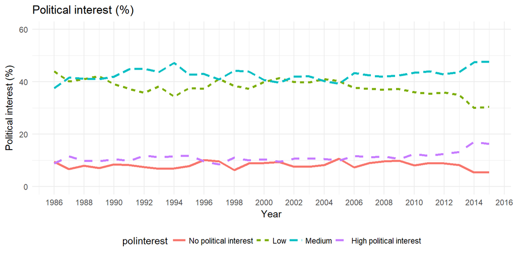

```r
supersom %>%
  select(polinterest, date) %>%
  na.exclude() %>%
  group_by(date, polinterest) %>%
  summarize(n = n()) %>%
  mutate(percent = n / sum(n) * 100) %>%
  ggplot(aes(date, percent, color=polinterest, linetype=polinterest)) +
    geom_line(size=1.1) +
    scale_y_continuous(labels=scales::comma, limits=c(0, 60)) +
    scale_x_date(date_label="%Y", date_breaks="2 year") +
    theme(legend.position="bottom") +
    labs(title="Political interest (%)",
       subtitle=NULL,
       x="Year",
       y="Political interest (%)")
```

Dichotomize political interest.

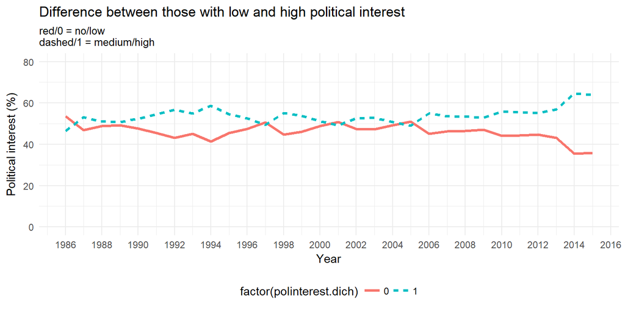

```r
supersom %>%
  select(polinterest.num, date) %>%
  mutate(polinterest.dich = case_when(polinterest.num %in% c(3, 4) ~ 1, TRUE ~ 0)) %>%
  na.exclude() %>%
  group_by(date, polinterest.dich) %>%
  summarize(n = n()) %>%
  mutate(percent = n / sum(n) * 100) %>%
  ggplot(aes(date, percent, color=factor(polinterest.dich), linetype=factor(polinterest.dich))) +
    geom_line(size=1.1) +
    #geom_smooth(method = "loess", level=0.95, color="blue", alpha=0.3) +
    scale_y_continuous(labels=scales::comma, limits=c(0, 80)) +
    scale_x_date(date_label="%Y", date_breaks="2 year") +
    theme(legend.position="bottom") +
    labs(title="Difference between those with low and high political interest",
       subtitle="red/0 = no/low\ndashed/1 = medium/high",
       x="Year",
       y="Political interest (%)")
```

### 3.3.2 Political leaning

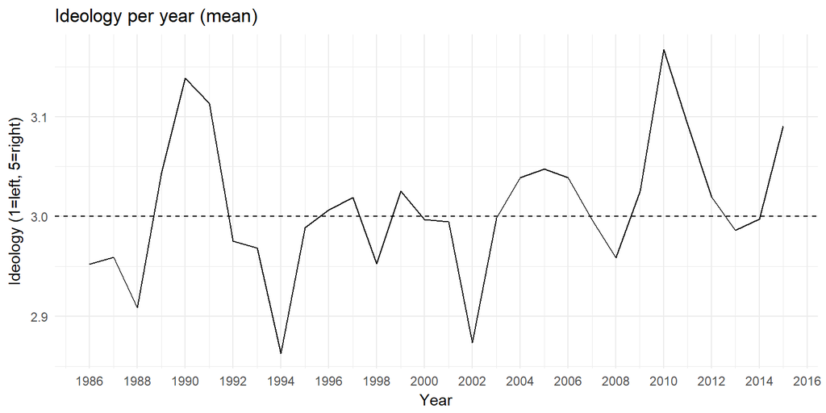

```r
supersom %>%
   group_by(date) %>%
   select(date, ideology) %>%
   summarize(meanideology=mean(ideology, na.rm=TRUE)) %>%
   ggplot(aes(date, meanideology)) +
    geom_line() +
    #geom_smooth(method = "lm", level=0.95) +
    scale_y_continuous(labels=scales::comma) +
    scale_x_date(date_label="%Y", date_breaks="2 year") +
    geom_hline(yintercept=3, linetype=2) +
    labs(title="Ideology per year (mean)", x="Year", y="Ideology (1=left, 5=right)")
```

### 3.3.3 Extreme ideology

Ideological extremism by year.

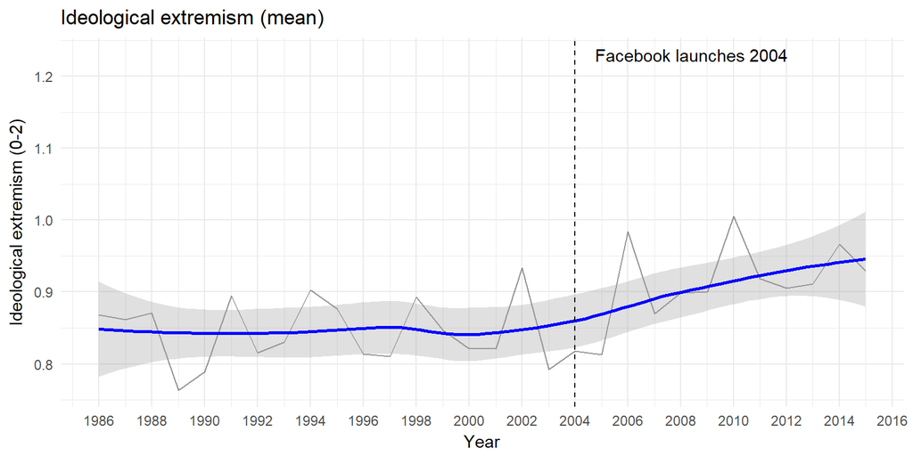

```r
supersom %>%
  group_by(date) %>%
  select(date, polextreme) %>%
  summarize(meanextremism=mean(polextreme, na.rm=TRUE)) %>%
  ggplot(aes(date, meanextremism)) +
    geom_line(alpha=0.4) +
    geom_smooth(method = "loess", level=0.95, color="blue", alpha=0.3) +
    scale_y_continuous(labels=scales::comma) +
    scale_x_date(date_label="%Y", date_breaks="2 year") +
    labs(title="Ideological extremism (mean)",
         subtitle=NULL,
         x="Year",
         y="Ideological extremism (0-2)") +
    geom_vline(xintercept = as.numeric(as.Date("2004-01-01")), color="black", alpha=0.9, linetype=2) +
    #geom_vline(xintercept = as.numeric(as.Date("2006-01-01")), color="black", alpha=0.9, linetype=4)
    annotate("text", x=as.Date("2008-06-01"), y=1.23, label="Facebook launches 2004")
```

Ideological extremism by party block.

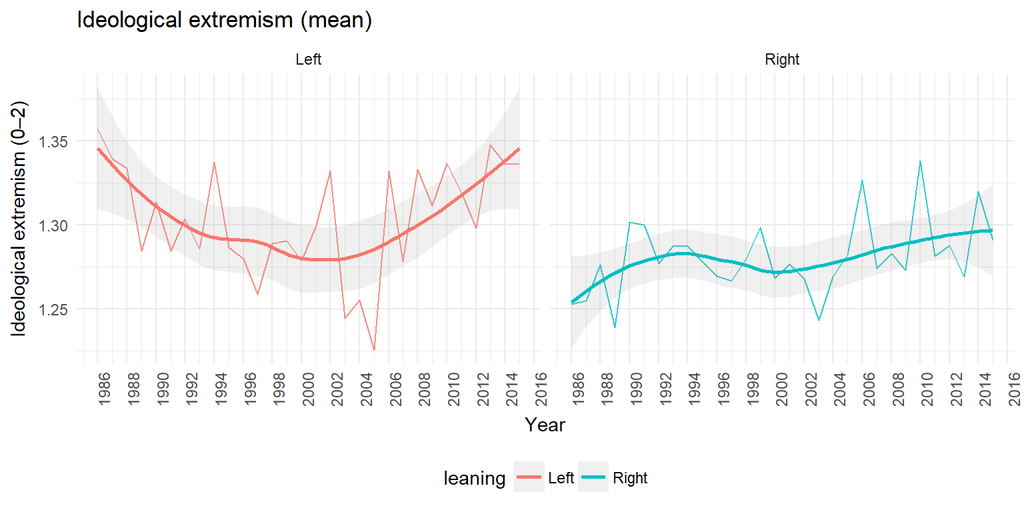

```r
supersom %>%
  group_by(leaning, date) %>%
  select(date, polextreme, leaning) %>%
  na.exclude() %>%
  summarize(meanextremism=mean(polextreme, na.rm=TRUE)) %>%
  filter(meanextremism > 0) %>%
  ggplot(aes(date, meanextremism, color=leaning)) +
    geom_line(alpha=0.8) +
    geom_smooth(method = "loess", level=0.95, alpha=0.15) +
    scale_y_continuous(labels=scales::comma) +
    scale_x_date(date_label="%Y", date_breaks="2 year") +
    theme(legend.position = "bottom", axis.text.x = element_text(angle=90)) +
    labs(title="Ideological extremism (mean)",
         subtitle=NULL,
         x="Year",
         y="Ideological extremism (0–2)") +
    facet_grid(~leaning)
```

# 4 Regresion models

## 4.1 Setup

Prepare models, load libraries. Create a fuction for mixed-effects regression coefficient plots.

```r
library(lme4)
```

```r
library(sjlabelled)
library(sjPlot)
library(directlabels)
library(effects)
# Coefficient plot.
coefplot_mlm <- function(model, intercept=FALSE, sort=FALSE, title="Predictors", caption="Bars represent 95 % C.I.", labels=NULL, nudge_y=0.3, nudge_x=0) {
  library(broom)
  df <- tidy(model, conf.int=TRUE) %>%
    mutate(label = paste(round(estimate, 2), sep=""))
  if(!is.null(labels)) {
    # Rename labels.
    df$term <- labels
  }
  if(sort == TRUE) {
    df$term <- reorder(df$term, df$estimate)  # Sort by estimate, descdending order.
  }
  if(intercept == FALSE){
    df <- df %>% filter(term != "(Intercept)")
  }
  df %>%
    na.exclude() %>%
    ggplot(aes(estimate, term)) +
    geom_point(size=3, fill="black") +
    geom_errorbarh(aes(xmin=conf.low, xmax=conf.high), width=0.2, height=0, lwd=1, lty=1, col="black") +
    geom_vline(xintercept = 0, color="black", alpha=0.5, linetype=2) +
    geom_text(aes(label=label, alpha=1), nudge_y=nudge_y, nudge_x=nudge_x) +
    theme(legend.position = "none") +
    labs(title=title,
         caption=caption,
         x="Estimate",
         y=NULL)
}
```

Prepare data for models: set reference category and center variables.

```r
# Set reference categories.
supersom$polinterest <- relevel(supersom$polinterest, ref="No political interest")
supersom$party <- relevel(supersom$party, ref="Social Democrats (S)")
supersom$leaning <- relevel(supersom$leaning, ref="Center")
supersom$psuse <- relevel(supersom$psuse, ref="PS news more seldom")
supersom$psuse.daily <- relevel(supersom$psuse.daily, ref="PS news more seldom")
supersom$trust.svt.dich <- relevel(supersom$trust.svt.dich, ref="Low trust")
supersom$trust.sr.dich <- relevel(supersom$trust.sr.dich, ref="Low trust")

# Center year 1986 as 1.
supersom$time <- 1 + supersom$year - 1986
```

## 4.2 Descriptives

Mean public service news use by year, including standard deviation.

```r
supersom %>% group_by(year) %>% summarize(psindex = mean(psindex.rev, na.rm=TRUE), psindex.stddev = sd(psindex.rev, na.rm=TRUE))
```

```
## # A tibble: 30 x 3
##     year psindex psindex.stddev
##    <dbl>   <dbl>          <dbl>
##  1  1986    3.70           1.17
##  2  1987    3.75           1.17
##  3  1988    3.70           1.17
##  4  1989    3.76           1.16
##  5  1990    3.83           1.19
##  6  1991    3.72           1.21
##  7  1992    3.70           1.19
##  8  1993    3.65           1.22
##  9  1994    3.65           1.26
## 10  1995    3.57           1.31
## # ... with 20 more rows
```

## 4.3 Model 1 (empty model)

Empty model with dependent variable + year as random intercept.

```r
mlm1 <- lmer(psindex.rev ~ 1 + (1 | time), data=supersom, REML=FALSE)
summary(mlm1)
```

```
## Linear mixed model fit by maximum likelihood  ['lmerMod']
## Formula: psindex.rev ~ 1 + (1 | time)
##    Data: supersom
##
##       AIC       BIC    logLik  deviance  df.resid
##  309955.1  309983.2 -154974.5  309949.1     88614
##
## Scaled residuals:
##     Min      1Q  Median      3Q     Max
## -2.0143 -0.8376 -0.1137  0.6458  1.7837
##
## Random effects:
##  Groups   Name        Variance Std.Dev.
##  time     (Intercept) 0.00395  0.06285
##  Residual             1.93309  1.39036
## Number of obs: 88617, groups:  time, 30
##
## Fixed effects:
##             Estimate Std. Error t value
## (Intercept)   3.6911     0.0126   292.9
```

## 4.4 Model 2 A-C (political interest, leaning, party)

Year as random intercept + political interest as fixed slope.

Year as random intercept + political leaning as fixed slope.

Year as random intercept + party as fixed slope.

```r
mlm2a <- lmer(psindex.rev ~ 1 + time + polinterest + (1 | time), data=supersom, REML=FALSE)
summary(mlm2a)
```

```
## Linear mixed model fit by maximum likelihood  ['lmerMod']
## Formula: psindex.rev ~ 1 + time + polinterest + (1 | time)
##    Data: supersom
##
##       AIC       BIC    logLik  deviance  df.resid
##  294822.0  294887.7 -147404.0  294808.0     87388
##
## Scaled residuals:
##      Min       1Q   Median       3Q      Max
## -2.69379 -0.73401 -0.00648  0.76590  2.73277
##
## Random effects:
##  Groups   Name        Variance Std.Dev.
##  time     (Intercept) 0.005753 0.07585
##  Residual             1.706808 1.30645
## Number of obs: 87395, groups:  time, 30
##
## Fixed effects:
##                                     Estimate Std. Error t value
## (Intercept)                         2.632472   0.034365   76.60
## time                               -0.002927   0.001703   -1.72
## polinterestLow                      0.789839   0.017340   45.55
## polinterestMedium                   1.405913   0.017114   82.15
## polinterestHigh political interest  1.768394   0.020230   87.42
##
## Correlation of Fixed Effects:
##             (Intr) time   plntrL plntrM
## time        -0.790
## polintrstLw -0.418  0.004
## polntrstMdm -0.419 -0.001  0.833
## plntrstHgpi -0.349 -0.007  0.705  0.717
```

```r
mlm2b <- lmer(psindex.rev ~ 1 + time + leaning + (1 | time), data=supersom, REML=FALSE)
summary(mlm2b)
```

```
## Linear mixed model fit by maximum likelihood  ['lmerMod']
## Formula: psindex.rev ~ 1 + time + leaning + (1 | time)
##    Data: supersom
##
##       AIC       BIC    logLik  deviance  df.resid
##  299660.9  299717.1 -149824.4  299648.9     86045
##
## Scaled residuals:
##      Min       1Q   Median       3Q      Max
## -2.12650 -0.75416 -0.01242  0.77270  1.91046
##
## Random effects:
##  Groups   Name        Variance Std.Dev.
##  time     (Intercept) 0.003796 0.06161
##  Residual             1.903542 1.37969
## Number of obs: 86051, groups:  time, 30
##
## Fixed effects:
##               Estimate Std. Error t value
## (Intercept)   3.543880   0.027236  130.12
## time         -0.001578   0.001441   -1.10
## leaningLeft   0.242864   0.011780   20.62
## leaningRight  0.293495   0.011618   25.26
##
## Correlation of Fixed Effects:
##             (Intr) time   lnngLf
## time        -0.852
## leaningLeft -0.211 -0.015
## leaningRght -0.209 -0.020  0.533
```

```r
mlm2c <- lmer(psindex.rev ~ 1 + time +  party + (1 | time), data=supersom, REML=FALSE)
summary(mlm2c)
```

```
## Linear mixed model fit by maximum likelihood  ['lmerMod']
## Formula: psindex.rev ~ 1 + time + party + (1 | time)
##    Data: supersom
##
##       AIC       BIC    logLik  deviance  df.resid
##  281310.3  281449.9 -140640.2  281280.3     81138
##
## Scaled residuals:
##     Min      1Q  Median      3Q     Max
## -2.2275 -0.7662 -0.0148  0.7904  2.6446
##
## Random effects:
##  Groups   Name        Variance Std.Dev.
##  time     (Intercept) 0.003424 0.05851
##  Residual             1.873010 1.36858
## Number of obs: 81153, groups:  time, 30
##
## Fixed effects:
##                                Estimate Std. Error t value
## (Intercept)                    3.711892   0.026448  140.34
## time                           0.001700   0.001395    1.22
## partyLeft Party (V)           -0.100862   0.019356   -5.21
## partyCentre Party (C)          0.202994   0.021592    9.40
## partyLiberals (L)              0.110847   0.018651    5.94
## partyModerate Party (M)        0.024208   0.012880    1.88
## partyChristian Democrats (KD)  0.180575   0.022541    8.01
## partyGreen Party (MP)         -0.316469   0.018983  -16.67
## partySweden Democrats (SD)    -0.334814   0.027139  -12.34
## partyFeminist Initiative (FI) -0.298670   0.064647   -4.62
## partyPirate Party (PP)        -1.458968   0.080685  -18.08
## partyNew Democracy (NyD)      -0.252710   0.076103   -3.32
## partyOther                    -0.499747   0.034561  -14.46
```

```
##
## Correlation matrix not shown by default, as p = 13 > 12.
## Use print(x, correlation=TRUE)  or
##   vcov(x)     if you need it
```

```r
mlm2d <- lmer(psindex.rev ~ 1 + time + factor(polinterest) + leaning + (1 | time), data=supersom, REML=FALSE)
summary(mlm2d)
```

```
## Linear mixed model fit by maximum likelihood  ['lmerMod']
## Formula: psindex.rev ~ 1 + time + factor(polinterest) + leaning + (1 |
##     time)
##    Data: supersom
##
##       AIC       BIC    logLik  deviance  df.resid
##  287518.5  287602.7 -143750.3  287500.5     85292
##
## Scaled residuals:
##      Min       1Q   Median       3Q      Max
## -2.73119 -0.72900 -0.00856  0.77131  2.72800
##
## Random effects:
##  Groups   Name        Variance Std.Dev.
##  time     (Intercept) 0.005559 0.07456
##  Residual             1.701933 1.30458
## Number of obs: 85301, groups:  time, 30
##
## Fixed effects:
##                                             Estimate Std. Error t value
## (Intercept)                                 2.636428   0.034482   76.46
## time                                       -0.002843   0.001681   -1.69
## factor(polinterest)Low                      0.773920   0.018025   42.94
## factor(polinterest)Medium                   1.381687   0.018019   76.68
## factor(polinterest)High political interest  1.746914   0.021128   82.68
## leaningLeft                                -0.007951   0.011469   -0.69
## leaningRight                                0.057095   0.011292    5.06
##
## Correlation of Fixed Effects:
##             (Intr) time   fct()L fct()M f()Hpi lnngLf
## time        -0.777
## fctr(plnt)L -0.418  0.006
## fctr(plnt)M -0.405  0.002  0.841
## fctr(pl)Hpi -0.337 -0.004  0.721  0.739
## leaningLeft -0.096 -0.010 -0.098 -0.172 -0.177
## leaningRght -0.090 -0.014 -0.110 -0.182 -0.169  0.554
```

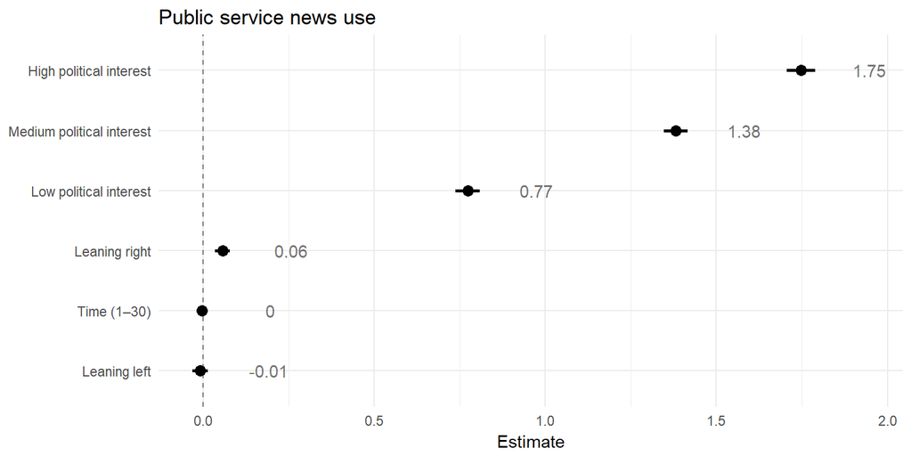

```r
coefplot_mlm(mlm2d, title="Public service news use", caption=NULL, sort=TRUE, nudge_y=0, nudge_x=0.2,
             labels=c("(Intercept)", "Time (1–30)", "Low political interest", "Medium political interest", "High political interest","Leaning left", "Leaning right", "", ""))
```

```r
sjt.lmer(mlm2a, mlm2b, mlm2c, p.kr=FALSE)
```

```
## Computing p-values via Wald-statistics approximation (treating t as Wald z).
```

```
## Computing p-values via Wald-statistics approximation (treating t as Wald z).
## Computing p-values via Wald-statistics approximation (treating t as Wald z).
```

|  |  | B | CI | p |  | B | CI | p |  | B | CI | p |
| --- | --- | --- | --- | --- | --- | --- | --- | --- | --- | --- | --- | --- |
| Fixed Parts |  |  |  |  |  |  |  |  |  |  |  |  |
| (Intercept) |  | 2.63 | 2.57 – 2.70 | <.001 |  | 3.54 | 3.49 – 3.60 | <.001 |  | 3.71 | 3.66 – 3.76 | <.001 |
| Undersökningsår |  | -0.00 | -0.01 – 0.00 | .086 |  | -0.00 | -0.00 – 0.00 | .273 |  | 0.00 | -0.00 – 0.00 | .223 |
| polinterest (Low) |  | 0.79 | 0.76 – 0.82 | <.001 |  |  |  |  |  |  |  |  |
| polinterest (Medium) |  | 1.41 | 1.37 – 1.44 | <.001 |  |  |  |  |  |  |  |  |
| polinterest (High political interest) |  | 1.77 | 1.73 – 1.81 | <.001 |  |  |  |  |  |  |  |  |
| leaning (Left) |  |  |  |  |  | 0.24 | 0.22 – 0.27 | <.001 |  |  |  |  |
| leaning (Right) |  |  |  |  |  | 0.29 | 0.27 – 0.32 | <.001 |  |  |  |  |
| party (Left Party (V)) |  |  |  |  |  |  |  |  |  | -0.10 | -0.14 – -0.06 | <.001 |
| party (Centre Party (C)) |  |  |  |  |  |  |  |  |  | 0.20 | 0.16 – 0.25 | <.001 |
| party (Liberals (L)) |  |  |  |  |  |  |  |  |  | 0.11 | 0.07 – 0.15 | <.001 |
| party (Moderate Party (M)) |  |  |  |  |  |  |  |  |  | 0.02 | -0.00 – 0.05 | .060 |
| party (Christian Democrats (KD)) |  |  |  |  |  |  |  |  |  | 0.18 | 0.14 – 0.22 | <.001 |
| party (Green Party (MP)) |  |  |  |  |  |  |  |  |  | -0.32 | -0.35 – -0.28 | <.001 |
| party (Sweden Democrats (SD)) |  |  |  |  |  |  |  |  |  | -0.33 | -0.39 – -0.28 | <.001 |
| party (Feminist Initiative (FI)) |  |  |  |  |  |  |  |  |  | -0.30 | -0.43 – -0.17 | <.001 |
| party (Pirate Party (PP)) |  |  |  |  |  |  |  |  |  | -1.46 | -1.62 – -1.30 | <.001 |
| party (New Democracy (NyD)) |  |  |  |  |  |  |  |  |  | -0.25 | -0.40 – -0.10 | <.001 |
| party (Other) |  |  |  |  |  |  |  |  |  | -0.50 | -0.57 – -0.43 | <.001 |
| Random Parts |  |  |  |  |  |  |  |  |  |  |  |  |
| σ<sup>2</sup> |  | 1.707 |  |  |  | 1.904 |  |  |  | 1.873 |  |  |
| τ<sub>00, time</sub> |  | 0.006 |  |  |  | 0.004 |  |  |  | 0.003 |  |  |
| N<sub>time</sub> |  | 30 |  |  |  | 30 |  |  |  | 30 |  |  |
| ICC<sub>time</sub> |  | 0.003 |  |  |  | 0.002 |  |  |  | 0.002 |  |  |
| Observations |  | 87395 |  |  |  | 86051 |  |  |  | 81153 |  |  |
| R<sup>2</sup> / Ω<sub>0</sub><sup>2</sup> |  | .118 / .118 |  |  |  | .010 / .010 |  |  |  | .018 / .018 |  |  |

## 4.5 Model 3 (leaning, political interest)

Year as random intercept + everything else as fixed slope. With controls.

```r
mlm3 <- lmer(psindex.rev ~ 1 + leaning + polinterest + sex + age4a + edu3 + time + (1 | time), data=supersom, REML=FALSE)
summary(mlm3)
```

```
## Linear mixed model fit by maximum likelihood  ['lmerMod']
## Formula: psindex.rev ~ 1 + leaning + polinterest + sex + age4a + edu3 +
##     time + (1 | time)
##    Data: supersom
##
##       AIC       BIC    logLik  deviance  df.resid
##  257320.9  257460.6 -128645.5  257290.9     81552
##
## Scaled residuals:
##     Min      1Q  Median      3Q     Max
## -3.7732 -0.7192 -0.0749  0.7512  3.5876
##
## Random effects:
##  Groups   Name        Variance Std.Dev.
##  time     (Intercept) 0.005162 0.07185
##  Residual             1.371140 1.17096
## Number of obs: 81567, groups:  time, 29
##
## Fixed effects:
##                                                               Estimate
## (Intercept)                                                   2.140192
## leaningLeft                                                   0.054251
## leaningRight                                                  0.069055
## polinterestLow                                                0.518926
## polinterestMedium                                             0.949015
## polinterestHigh political interest                            1.236534
## sexMale                                                       0.145519
## age4a30-49 år                                                 0.636826
## age4a50-64 år                                                 1.218455
## age4a65--                                                     1.780546
## edu3Medel (allt över grundskola men ej högskola/universitet)  0.085248
## edu3Hög (studier/examen från högskola/universitet)            0.157586
## time                                                         -0.014551
##                                                              Std. Error
## (Intercept)                                                    0.035961
## leaningLeft                                                    0.010558
## leaningRight                                                   0.010480
## polinterestLow                                                 0.016903
## polinterestMedium                                              0.017216
## polinterestHigh political interest                             0.020326
## sexMale                                                        0.008378
## age4a30-49 år                                                  0.011786
## age4a50-64 år                                                  0.012808
## age4a65--                                                      0.014238
## edu3Medel (allt över grundskola men ej högskola/universitet)   0.011728
## edu3Hög (studier/examen från högskola/universitet)             0.012940
## time                                                           0.001688
##                                                              t value
## (Intercept)                                                    59.51
## leaningLeft                                                     5.14
## leaningRight                                                    6.59
## polinterestLow                                                 30.70
## polinterestMedium                                              55.12
## polinterestHigh political interest                             60.84
## sexMale                                                        17.37
## age4a30-49 år                                                  54.03
## age4a50-64 år                                                  95.13
## age4a65--                                                     125.05
## edu3Medel (allt över grundskola men ej högskola/universitet)    7.27
## edu3Hög (studier/examen från högskola/universitet)             12.18
## time                                                           -8.62
```

```
##
## Correlation matrix not shown by default, as p = 13 > 12.
## Use print(x, correlation=TRUE)  or
##   vcov(x)     if you need it
```

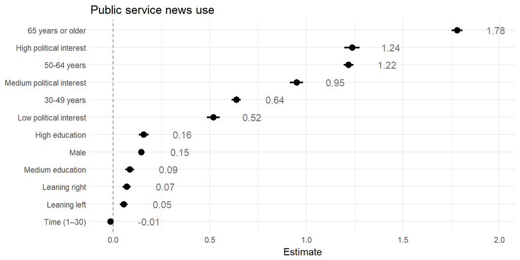

```r
coefplot_mlm(mlm3, title="Public service news use", caption=NULL, sort=TRUE, nudge_y=0, nudge_x=0.2,
             labels=c("(Intercept)", "Leaning left", "Leaning right", "Low political interest", "Medium political interest", "High political interest", "Male", "30-49 years", "50-64 years", "65 years or older", "Medium education", "High education", "Time (1–30)", "", ""))
```

Correlation matrix.

```r
print(mlm3, correlation=TRUE)
```

```
## Linear mixed model fit by maximum likelihood  ['lmerMod']
## Formula: psindex.rev ~ 1 + leaning + polinterest + sex + age4a + edu3 +
##     time + (1 | time)
##    Data: supersom
##       AIC       BIC    logLik  deviance  df.resid
##  257320.9  257460.6 -128645.5  257290.9     81552
## Random effects:
##  Groups   Name        Std.Dev.
##  time     (Intercept) 0.07185
##  Residual             1.17096
## Number of obs: 81567, groups:  time, 29
## Fixed Effects:
##                                                  (Intercept)
##                                                      2.14019
##                                                  leaningLeft
##                                                      0.05425
##                                                 leaningRight
##                                                      0.06906
##                                               polinterestLow
##                                                      0.51893
##                                            polinterestMedium
##                                                      0.94902
##                           polinterestHigh political interest
##                                                      1.23653
##                                                      sexMale
##                                                      0.14552
##                                                age4a30-49 år
##                                                      0.63683
##                                                age4a50-64 år
##                                                      1.21846
##                                                    age4a65--
##                                                      1.78055
## edu3Medel (allt över grundskola men ej högskola/universitet)
##                                                      0.08525
##           edu3Hög (studier/examen från högskola/universitet)
##                                                      0.15759
##                                                         time
##                                                     -0.01455
```

## 4.6 Model 4 (leaning, political interest, party, party strength)

Add political party identity + party strength. With controls.

```r
mlm4 <- lmer(psindex.rev ~ 1 + leaning + polinterest + party + partystrength + sex + age4a + edu3 + time + (1 | time), data=supersom, REML=FALSE)
summary(mlm4)
```

```
## Linear mixed model fit by maximum likelihood  ['lmerMod']
## Formula:
## psindex.rev ~ 1 + leaning + polinterest + party + partystrength +
##     sex + age4a + edu3 + time + (1 | time)
##    Data: supersom
##
##       AIC       BIC    logLik  deviance  df.resid
##  234816.6  235074.8 -117380.3  234760.6     74670
##
## Scaled residuals:
##     Min      1Q  Median      3Q     Max
## -3.7590 -0.7184 -0.0743  0.7526  3.7371
##
## Random effects:
##  Groups   Name        Variance Std.Dev.
##  time     (Intercept) 0.004758 0.06898
##  Residual             1.355359 1.16420
## Number of obs: 74698, groups:  time, 29
##
## Fixed effects:
##                                                               Estimate
## (Intercept)                                                   2.128899
## leaningLeft                                                   0.057692
## leaningRight                                                  0.045924
## polinterestLow                                                0.505401
## polinterestMedium                                             0.927140
## polinterestHigh political interest                            1.225968
## partyLeft Party (V)                                          -0.039004
## partyCentre Party (C)                                         0.167363
## partyLiberals (L)                                             0.082587
## partyModerate Party (M)                                      -0.023523
## partyChristian Democrats (KD)                                 0.038053
## partyGreen Party (MP)                                        -0.084580
## partySweden Democrats (SD)                                   -0.185225
## partyFeminist Initiative (FI)                                -0.110301
## partyPirate Party (PP)                                       -0.634575
## partyNew Democracy (NyD)                                      0.063067
## partyOther                                                   -0.168087
## partystrengthWeak party supporter                             0.038239
## partystrengthStrong party supporter                          -0.003369
```

[output cut: 46 more lines]

```
## partyGreen Party (MP)                                          -4.88
## partySweden Democrats (SD)                                     -7.39
## partyFeminist Initiative (FI)                                  -1.95
## partyPirate Party (PP)                                         -8.92
## partyNew Democracy (NyD)                                        0.91
## partyOther                                                     -4.99
## partystrengthWeak party supporter                               3.91
## partystrengthStrong party supporter                            -0.25
## sexMale                                                        17.89
## age4a30-49 år                                                  49.95
## age4a50-64 år                                                  88.70
## age4a65--                                                     115.95
## edu3Medel (allt över grundskola men ej högskola/universitet)    7.34
## edu3Hög (studier/examen från högskola/universitet)             11.76
## time                                                           -7.52
```

```
##
## Correlation matrix not shown by default, as p = 26 > 12.
## Use print(x, correlation=TRUE)  or
##   vcov(x)     if you need it
```

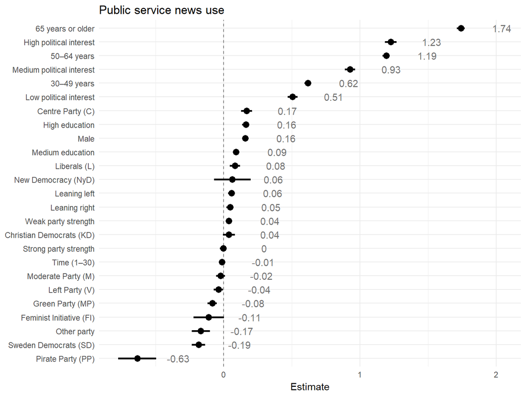

```r
coefplot_mlm(mlm4, title="Public service news use", intercept=FALSE, caption=NULL, sort=TRUE, nudge_y=0, nudge_x=0.3,
             labels=c("(Intercept)", "Leaning left", "Leaning right", "Low political interest", "Medium political interest", "High political interest", "Left Party (V)", "Centre Party (C)", "Liberals (L)", "Moderate Party (M)", "Christian Democrats (KD)", "Green Party (MP)", "Sweden Democrats (SD)", "Feminist Initiative (FI)", "Pirate Party (PP)", "New Democracy (NyD)", "Other party", "Weak party strength", "Strong party strength", "Male", "30–49 years", "50–64 years", "65 years or older", "Medium education", "High education", "Time (1–30)", "", ""))
```

Plot of random effects.

```r
sjp.lmer(mlm4)
```

```
## Plotting random effects...
```

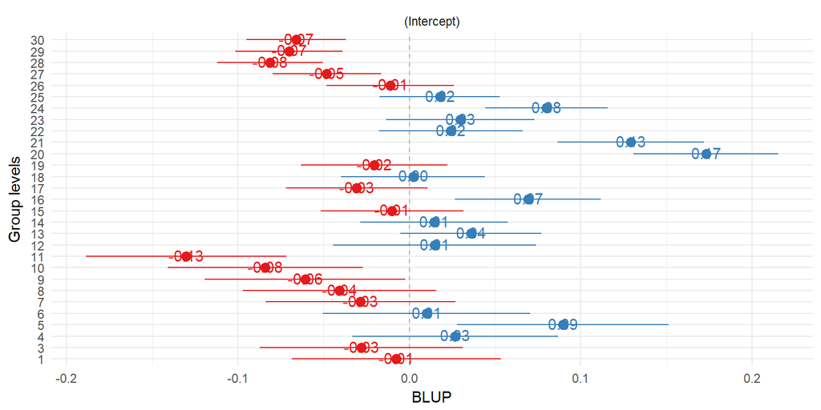

Correlation matrix of fixed effects.

```r
sjp.lmer(mlm4, type = "fe.cor")
```

```
## Computing correlation using pearson-method with listwise-deletion...
```

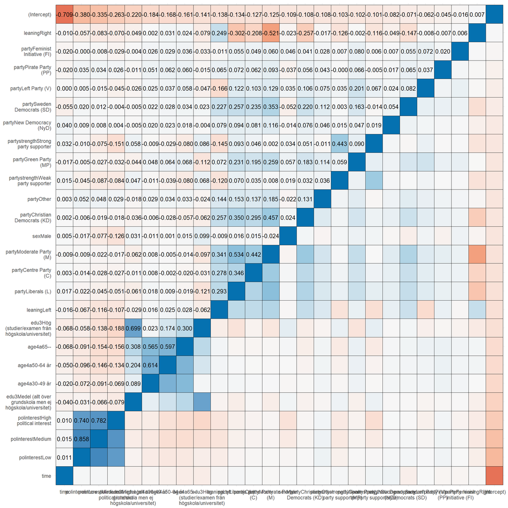

qq-plot of random effects.

```
## Testing for normal distribution. Dots should be plotted along the line.
```

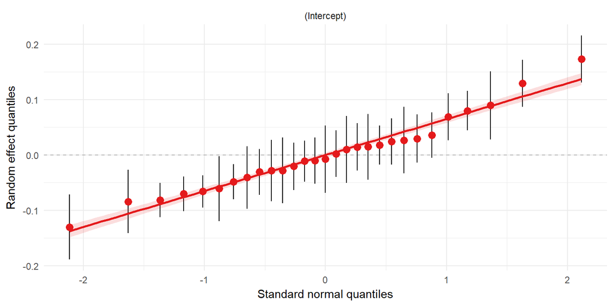

```r
sjp.lmer(mlm4, type = "re.qq")
```

## 4.7 Tables of model 2 A-C (bivariate)

Bivariate model for each political preference.

```r
# Test without variable time.
mlm2a_notime <- lmer(psindex.rev ~ 1 + polinterest + (1 | time), data=supersom, REML=FALSE)
mlm2b_notime <- lmer(psindex.rev ~ 1 + leaning + (1 | time), data=supersom, REML=FALSE)
mlm2c_notime <- lmer(psindex.rev ~ 1 + party + (1 | time), data=supersom, REML=FALSE)

# No differences.
anova(mlm2a, mlm2a_notime)
```

```
## Data: supersom
## Models:
## mlm2a_notime: psindex.rev ~ 1 + polinterest + (1 | time)
## mlm2a: psindex.rev ~ 1 + time + polinterest + (1 | time)
##              Df    AIC    BIC  logLik deviance  Chisq Chi Df Pr(>Chisq)
## mlm2a_notime  6 294823 294879 -147405   294811
## mlm2a         7 294822 294888 -147404   294808 2.7982      1    0.09437 .
## ---
## Signif. codes:  0 '***' 0.001 '**' 0.01 '*' 0.05 '.' 0.1 ' ' 1
```

```r
anova(mlm2c, mlm2c_notime)
```

```
## Data: supersom
## Models:
## mlm2c_notime: psindex.rev ~ 1 + party + (1 | time)
## mlm2c: psindex.rev ~ 1 + time + party + (1 | time)
##              Df    AIC    BIC  logLik deviance  Chisq Chi Df Pr(>Chisq)
## mlm2c_notime 14 281310 281440 -140641   281282
## mlm2c        15 281310 281450 -140640   281280 1.4439      1     0.2295
```

```r
anova(mlm2c, mlm2c_notime)
```

```
## Data: supersom
## Models:
## mlm2c_notime: psindex.rev ~ 1 + party + (1 | time)
## mlm2c: psindex.rev ~ 1 + time + party + (1 | time)
##              Df    AIC    BIC  logLik deviance  Chisq Chi Df Pr(>Chisq)
## mlm2c_notime 14 281310 281440 -140641   281282
## mlm2c        15 281310 281450 -140640   281280 1.4439      1     0.2295
```

```r
# Then use the simpler model, without time.
sjt.lmer(mlm2a_notime, mlm2b_notime, mlm2c_notime, p.kr = FALSE)
```

```
## Computing p-values via Wald-statistics approximation (treating t as Wald z).
## Computing p-values via Wald-statistics approximation (treating t as Wald z).
## Computing p-values via Wald-statistics approximation (treating t as Wald z).
```

|  |  | B | CI | p |  | B | CI | p |  | B | CI | p |
| --- | --- | --- | --- | --- | --- | --- | --- | --- | --- | --- | --- | --- |
| Fixed Parts |  |  |  |  |  |  |  |  |  |  |  |  |
| (Intercept) |  | 2.59 | 2.54 – 2.63 | <.001 |  | 3.52 | 3.49 – 3.55 | <.001 |  | 3.74 | 3.71 – 3.77 | <.001 |
| polinterest (Low) |  | 0.79 | 0.76 – 0.82 | <.001 |  |  |  |  |  |  |  |  |
| polinterest (Medium) |  | 1.41 | 1.37 – 1.44 | <.001 |  |  |  |  |  |  |  |  |
| polinterest (High political interest) |  | 1.77 | 1.73 – 1.81 | <.001 |  |  |  |  |  |  |  |  |
| leaning (Left) |  |  |  |  |  | 0.24 | 0.22 – 0.27 | <.001 |  |  |  |  |
| leaning (Right) |  |  |  |  |  | 0.29 | 0.27 – 0.32 | <.001 |  |  |  |  |
| party (Left Party (V)) |  |  |  |  |  |  |  |  |  | -0.10 | -0.14 – -0.06 | <.001 |
| party (Centre Party (C)) |  |  |  |  |  |  |  |  |  | 0.20 | 0.16 – 0.25 | <.001 |
| party (Liberals (L)) |  |  |  |  |  |  |  |  |  | 0.11 | 0.07 – 0.15 | <.001 |
| party (Moderate Party (M)) |  |  |  |  |  |  |  |  |  | 0.02 | -0.00 – 0.05 | .056 |
| party (Christian Democrats (KD)) |  |  |  |  |  |  |  |  |  | 0.18 | 0.14 – 0.22 | <.001 |
| party (Green Party (MP)) |  |  |  |  |  |  |  |  |  | -0.32 | -0.35 – -0.28 | <.001 |
| party (Sweden Democrats (SD)) |  |  |  |  |  |  |  |  |  | -0.33 | -0.39 – -0.28 | <.001 |
| party (Feminist Initiative (FI)) |  |  |  |  |  |  |  |  |  | -0.30 | -0.42 – -0.17 | <.001 |
| party (Pirate Party (PP)) |  |  |  |  |  |  |  |  |  | -1.46 | -1.62 – -1.30 | <.001 |
| party (New Democracy (NyD)) |  |  |  |  |  |  |  |  |  | -0.26 | -0.41 – -0.11 | <.001 |
| party (Other) |  |  |  |  |  |  |  |  |  | -0.50 | -0.57 – -0.43 | <.001 |
| Random Parts |  |  |  |  |  |  |  |  |  |  |  |  |
| σ<sup>2</sup> |  | 1.707 |  |  |  | 1.904 |  |  |  | 1.873 |  |  |
| τ<sub>00, time</sub> |  | 0.006 |  |  |  | 0.004 |  |  |  | 0.004 |  |  |
| N<sub>time</sub> |  | 30 |  |  |  | 30 |  |  |  | 30 |  |  |
| ICC<sub>time</sub> |  | 0.004 |  |  |  | 0.002 |  |  |  | 0.002 |  |  |
| Observations |  | 87395 |  |  |  | 86051 |  |  |  | 81153 |  |  |
| R<sup>2</sup> / Ω<sub>0</sub><sup>2</sup> |  | .118 / .118 |  |  |  | .010 / .010 |  |  |  | .018 / .018 |  |  |

## 4.8 Tables of model 3-4 (multivariate)

```r
# Multivariate.
sjt.lmer(mlm3, mlm4, p.kr = FALSE
         #showHeaderStrings = TRUE,
         #stringB = "B",
         #stringCI = "95 % C.I.",
         #stringP = "p"
         #stringDependentVariables = "Response",
         #stringPredictors = "Coefficients",
         #stringIntercept = "Konstante",
         #separateConfColumn = FALSE,
         #showStdBeta = FALSE,
         #pvaluesAsNumbers = FALSE
         )
```

```
## Computing p-values via Wald-statistics approximation (treating t as Wald z).
## Computing p-values via Wald-statistics approximation (treating t as Wald z).
```

|  |  | B | CI | p |  | B | CI | p |
| --- | --- | --- | --- | --- | --- | --- | --- | --- |
| Fixed Parts |  |  |  |  |  |  |  |  |
| (Intercept) |  | 2.14 | 2.07 – 2.21 | <.001 |  | 2.13 | 2.06 – 2.20 | <.001 |
| leaning (Left) |  | 0.05 | 0.03 – 0.07 | <.001 |  | 0.06 | 0.03 – 0.08 | <.001 |
| leaning (Right) |  | 0.07 | 0.05 – 0.09 | <.001 |  | 0.05 | 0.02 – 0.07 | <.001 |
| polinterest (Low) |  | 0.52 | 0.49 – 0.55 | <.001 |  | 0.51 | 0.47 – 0.54 | <.001 |
| polinterest (Medium) |  | 0.95 | 0.92 – 0.98 | <.001 |  | 0.93 | 0.89 – 0.96 | <.001 |
| polinterest (High political interest) |  | 1.24 | 1.20 – 1.28 | <.001 |  | 1.23 | 1.18 – 1.27 | <.001 |
| sex (Male) |  | 0.15 | 0.13 – 0.16 | <.001 |  | 0.16 | 0.14 – 0.17 | <.001 |
| age4a (30-49 år) |  | 0.64 | 0.61 – 0.66 | <.001 |  | 0.62 | 0.59 – 0.64 | <.001 |
| age4a (50-64 år) |  | 1.22 | 1.19 – 1.24 | <.001 |  | 1.19 | 1.17 – 1.22 | <.001 |
| age4a (65--) |  | 1.78 | 1.75 – 1.81 | <.001 |  | 1.74 | 1.71 – 1.77 | <.001 |
| edu3 (Medel (allt över grundskola men ej högskola/universitet)) |  | 0.09 | 0.06 – 0.11 | <.001 |  | 0.09 | 0.07 – 0.11 | <.001 |
| edu3 (Hög (studier/examen från högskola/universitet)) |  | 0.16 | 0.13 – 0.18 | <.001 |  | 0.16 | 0.13 – 0.19 | <.001 |
| Undersökningsår |  | -0.01 | -0.02 – -0.01 | <.001 |  | -0.01 | -0.02 – -0.01 | <.001 |
| party (Left Party (V)) |  |  |  |  |  | -0.04 | -0.07 – -0.00 | .026 |
| party (Centre Party (C)) |  |  |  |  |  | 0.17 | 0.13 – 0.21 | <.001 |
| party (Liberals (L)) |  |  |  |  |  | 0.08 | 0.04 – 0.12 | <.001 |
| party (Moderate Party (M)) |  |  |  |  |  | -0.02 | -0.06 – 0.01 | .155 |
| party (Christian Democrats (KD)) |  |  |  |  |  | 0.04 | -0.01 – 0.08 | .084 |
| party (Green Party (MP)) |  |  |  |  |  | -0.08 | -0.12 – -0.05 | <.001 |
| party (Sweden Democrats (SD)) |  |  |  |  |  | -0.19 | -0.23 – -0.14 | <.001 |
| party (Feminist Initiative (FI)) |  |  |  |  |  | -0.11 | -0.22 – 0.00 | .051 |
| party (Pirate Party (PP)) |  |  |  |  |  | -0.63 | -0.77 – -0.50 | <.001 |
| party (New Democracy (NyD)) |  |  |  |  |  | 0.06 | -0.07 – 0.20 | .360 |
| party (Other) |  |  |  |  |  | -0.17 | -0.23 – -0.10 | <.001 |
| partystrength (Weak party supporter) |  |  |  |  |  | 0.04 | 0.02 – 0.06 | <.001 |
| partystrength (Strong party supporter) |  |  |  |  |  | -0.00 | -0.03 – 0.02 | .799 |
| Random Parts |  |  |  |  |  |  |  |  |
| σ<sup>2</sup> |  | 1.371 |  |  |  | 1.355 |  |  |
| τ<sub>00, time</sub> |  | 0.005 |  |  |  | 0.005 |  |  |
| N<sub>time</sub> |  | 29 |  |  |  | 29 |  |  |
| ICC<sub>time</sub> |  | 0.004 |  |  |  | 0.003 |  |  |
| Observations |  | 81567 |  |  |  | 74698 |  |  |
| R<sup>2</sup> / Ω<sub>0</sub><sup>2</sup> |  | .286 / .286 |  |  |  | .285 / .285 |  |  |

## 4.9 Model interactions

Three models with interactions with all three preferences. Without controls.

```r
mlm_interaction_polint <- lmer(psindex.rev ~ 1 + time + polinterest + time : polinterest + (1 | time), data=supersom, REML=FALSE)
mlm_interaction_party <- lmer(psindex.rev ~ 1 + time + party + time : party + (1 | time), data=supersom, REML=FALSE)
mlm_interaction_leaning <- lmer(psindex.rev ~ 1 + time + leaning + time : leaning + (1 | time), data=supersom, REML=FALSE)

sjt.lmer(mlm_interaction_polint, mlm_interaction_party, mlm_interaction_leaning, p.kr = FALSE)
```

```
## Computing p-values via Wald-statistics approximation (treating t as Wald z).
## Computing p-values via Wald-statistics approximation (treating t as Wald z).
## Computing p-values via Wald-statistics approximation (treating t as Wald z).
```

|  |  | B | CI | p |  | B | CI | p |  | B | CI | p |
| --- | --- | --- | --- | --- | --- | --- | --- | --- | --- | --- | --- | --- |
| Fixed Parts |  |  |  |  |  |  |  |  |  |  |  |  |
| (Intercept) |  | 2.99 | 2.89 – 3.09 | <.001 |  | 3.66 | 3.60 – 3.72 | <.001 |  | 3.59 | 3.52 – 3.65 | <.001 |
| time |  | -0.02 | -0.03 – -0.02 | <.001 |  | 0.00 | 0.00 – 0.01 | .008 |  | -0.00 | -0.01 – -0.00 | .023 |
| polinterestLow |  | 0.50 | 0.41 – 0.59 | <.001 |  |  |  |  |  |  |  |  |
| polinterestMedium |  | 0.95 | 0.86 – 1.03 | <.001 |  |  |  |  |  |  |  |  |
| polinterestHigh political interest |  | 1.29 | 1.18 – 1.39 | <.001 |  |  |  |  |  |  |  |  |
| time:polinterestLow |  | 0.01 | 0.01 – 0.02 | <.001 |  |  |  |  |  |  |  |  |
| time:polinterestMedium |  | 0.02 | 0.02 – 0.03 | <.001 |  |  |  |  |  |  |  |  |
| time:polinterestHigh political interest |  | 0.02 | 0.02 – 0.03 | <.001 |  |  |  |  |  |  |  |  |
| partyLeft Party (V) |  |  |  |  |  | -0.18 | -0.28 – -0.08 | <.001 |  |  |  |  |
| partyCentre Party (C) |  |  |  |  |  | 0.24 | 0.14 – 0.35 | <.001 |  |  |  |  |
| partyLiberals (L) |  |  |  |  |  | 0.02 | -0.07 – 0.10 | .688 |  |  |  |  |
| partyModerate Party (M) |  |  |  |  |  | 0.22 | 0.15 – 0.29 | <.001 |  |  |  |  |
| partyChristian Democrats (KD) |  |  |  |  |  | 0.25 | 0.13 – 0.38 | <.001 |  |  |  |  |
| partyGreen Party (MP) |  |  |  |  |  | -0.21 | -0.32 – -0.11 | <.001 |  |  |  |  |
| partySweden Democrats (SD) |  |  |  |  |  | -1.48 | -1.96 – -1.00 | <.001 |  |  |  |  |
| partyFeminist Initiative (FI) |  |  |  |  |  | 1.72 | 0.45 – 3.00 | .008 |  |  |  |  |
| partyPirate Party (PP) |  |  |  |  |  | -0.94 | -2.70 – 0.82 | .296 |  |  |  |  |
| partyNew Democracy (NyD) |  |  |  |  |  | -0.38 | -1.66 – 0.90 | .558 |  |  |  |  |
| partyOther |  |  |  |  |  | -0.10 | -0.26 – 0.07 | .256 |  |  |  |  |
| time:partyLeft Party (V) |  |  |  |  |  | 0.00 | -0.00 – 0.01 | .108 |  |  |  |  |
| time:partyCentre Party (C) |  |  |  |  |  | -0.00 | -0.01 – 0.00 | .410 |  |  |  |  |
| time:partyLiberals (L) |  |  |  |  |  | 0.01 | 0.00 – 0.01 | .013 |  |  |  |  |
| time:partyModerate Party (M) |  |  |  |  |  | -0.01 | -0.01 – -0.01 | <.001 |  |  |  |  |
| time:partyChristian Democrats (KD) |  |  |  |  |  | -0.00 | -0.01 – 0.00 | .230 |  |  |  |  |
| time:partyGreen Party (MP) |  |  |  |  |  | -0.01 | -0.01 – -0.00 | .029 |  |  |  |  |
| time:partySweden Democrats (SD) |  |  |  |  |  | 0.04 | 0.02 – 0.06 | <.001 |  |  |  |  |
| time:partyFeminist Initiative (FI) |  |  |  |  |  | -0.07 | -0.12 – -0.03 | .002 |  |  |  |  |
| time:partyPirate Party (PP) |  |  |  |  |  | -0.02 | -0.09 – 0.05 | .547 |  |  |  |  |
| time:partyNew Democracy (NyD) |  |  |  |  |  | 0.02 | -0.15 – 0.20 | .797 |  |  |  |  |
| time:partyOther |  |  |  |  |  | -0.02 | -0.03 – -0.01 | <.001 |  |  |  |  |
| leaningLeft |  |  |  |  |  |  |  |  |  | 0.17 | 0.11 – 0.23 | <.001 |
| leaningRight |  |  |  |  |  |  |  |  |  | 0.24 | 0.18 – 0.30 | <.001 |
| time:leaningLeft |  |  |  |  |  |  |  |  |  | 0.00 | 0.00 – 0.01 | .013 |
| time:leaningRight |  |  |  |  |  |  |  |  |  | 0.00 | 0.00 – 0.01 | .038 |
| Random Parts |  |  |  |  |  |  |  |  |  |  |  |  |
| σ<sup>2</sup> |  | 1.704 |  |  |  | 1.870 |  |  |  | 1.903 |  |  |
| τ<sub>00, time</sub> |  | 0.006 |  |  |  | 0.004 |  |  |  | 0.004 |  |  |
| N<sub>time</sub> |  | 30 |  |  |  | 30 |  |  |  | 30 |  |  |
| ICC<sub>time</sub> |  | 0.003 |  |  |  | 0.002 |  |  |  | 0.002 |  |  |
| Observations |  | 87395 |  |  |  | 81153 |  |  |  | 86051 |  |  |
| R<sup>2</sup> / Ω<sub>0</sub><sup>2</sup> |  | .119 / .119 |  |  |  | .019 / .019 |  |  |  | .010 / .010 |  |  |

Interactions with all three preferences. With controls.

```r
mlm_interaction_polint <- lmer(psindex.rev ~ 1 + time + polinterest + time:polinterest + sex + edu3 + age4a + (1 | time), data=supersom, REML=FALSE)
mlm_interaction_party <- lmer(psindex.rev ~ 1 + time + party + time:party + sex + edu3 + age4a + (1 | time), data=supersom, REML=FALSE)
mlm_interaction_leaning <- lmer(psindex.rev ~ 1 + time + leaning + time:leaning + sex + edu3 + age4a + (1 | time), data=supersom, REML=FALSE)
mlm_interaction_partystrength <- lmer(psindex.rev ~ 1 + time + partystrength + time:partystrength + sex + edu3 + age4a + (1 | time), data=supersom, REML=FALSE)
```

Tables of interactions.

```r
sjt.lmer(mlm_interaction_polint, mlm_interaction_party, mlm_interaction_leaning, p.kr = FALSE)
```

```
## Computing p-values via Wald-statistics approximation (treating t as Wald z).
## Computing p-values via Wald-statistics approximation (treating t as Wald z).
## Computing p-values via Wald-statistics approximation (treating t as Wald z).
```

|  |  | B | CI | p |  | B | CI | p |  | B | CI | p |
| --- | --- | --- | --- | --- | --- | --- | --- | --- | --- | --- | --- | --- |
| Fixed Parts |  |  |  |  |  |  |  |  |  |  |  |  |
| (Intercept) |  | 2.46 | 2.36 – 2.56 | <.001 |  | 2.63 | 2.56 – 2.70 | <.001 |  | 2.61 | 2.55 – 2.68 | <.001 |
| time |  | -0.03 | -0.04 – -0.03 | <.001 |  | -0.01 | -0.01 – -0.01 | <.001 |  | -0.02 | -0.02 – -0.02 | <.001 |
| polinterestLow |  | 0.32 | 0.23 – 0.40 | <.001 |  |  |  |  |  |  |  |  |
| polinterestMedium |  | 0.57 | 0.49 – 0.66 | <.001 |  |  |  |  |  |  |  |  |
| polinterestHigh political interest |  | 0.78 | 0.68 – 0.88 | <.001 |  |  |  |  |  |  |  |  |
| sexMale |  | 0.15 | 0.13 – 0.16 | <.001 |  | 0.26 | 0.24 – 0.28 | <.001 |  | 0.24 | 0.22 – 0.26 | <.001 |
| edu3Medel (allt över grundskola men ej högskola/universitet) |  | 0.09 | 0.07 – 0.12 | <.001 |  | 0.17 | 0.15 – 0.20 | <.001 |  | 0.17 | 0.14 – 0.19 | <.001 |
| edu3Hög (studier/examen från högskola/universitet) |  | 0.17 | 0.14 – 0.19 | <.001 |  | 0.39 | 0.36 – 0.42 | <.001 |  | 0.38 | 0.35 – 0.40 | <.001 |
| age4a30-49 år |  | 0.64 | 0.62 – 0.67 | <.001 |  | 0.69 | 0.66 – 0.71 | <.001 |  | 0.71 | 0.68 – 0.73 | <.001 |
| age4a50-64 år |  | 1.22 | 1.20 – 1.25 | <.001 |  | 1.35 | 1.32 – 1.38 | <.001 |  | 1.38 | 1.35 – 1.40 | <.001 |
| age4a65-- |  | 1.78 | 1.76 – 1.81 | <.001 |  | 1.97 | 1.94 – 2.00 | <.001 |  | 2.00 | 1.97 – 2.03 | <.001 |
| time:polinterestLow |  | 0.01 | 0.01 – 0.02 | <.001 |  |  |  |  |  |  |  |  |
| time:polinterestMedium |  | 0.02 | 0.02 – 0.02 | <.001 |  |  |  |  |  |  |  |  |
| time:polinterestHigh political interest |  | 0.02 | 0.02 – 0.03 | <.001 |  |  |  |  |  |  |  |  |
| partyLeft Party (V) |  |  |  |  |  | 0.10 | 0.01 – 0.20 | .031 |  |  |  |  |
| partyCentre Party (C) |  |  |  |  |  | 0.11 | 0.02 – 0.21 | .021 |  |  |  |  |
| partyLiberals (L) |  |  |  |  |  | 0.13 | 0.05 – 0.21 | .002 |  |  |  |  |
| partyModerate Party (M) |  |  |  |  |  | 0.10 | 0.04 – 0.17 | .001 |  |  |  |  |
| partyChristian Democrats (KD) |  |  |  |  |  | 0.12 | 0.00 – 0.23 | .046 |  |  |  |  |
| partyGreen Party (MP) |  |  |  |  |  | 0.04 | -0.06 – 0.14 | .414 |  |  |  |  |
| partySweden Democrats (SD) |  |  |  |  |  | -0.35 | -0.78 – 0.08 | .112 |  |  |  |  |
| partyFeminist Initiative (FI) |  |  |  |  |  | 1.07 | -0.07 – 2.20 | .066 |  |  |  |  |
| partyPirate Party (PP) |  |  |  |  |  | -0.35 | -1.94 – 1.24 | .666 |  |  |  |  |
| partyNew Democracy (NyD) |  |  |  |  |  | 0.35 | -0.83 – 1.54 | .560 |  |  |  |  |
| partyOther |  |  |  |  |  | 0.16 | 0.01 – 0.32 | .040 |  |  |  |  |
| time:partyLeft Party (V) |  |  |  |  |  | -0.00 | -0.01 – 0.00 | .423 |  |  |  |  |
| time:partyCentre Party (C) |  |  |  |  |  | 0.00 | -0.00 – 0.01 | .372 |  |  |  |  |
| time:partyLiberals (L) |  |  |  |  |  | -0.00 | -0.01 – 0.00 | .521 |  |  |  |  |
| time:partyModerate Party (M) |  |  |  |  |  | -0.01 | -0.01 – -0.00 | <.001 |  |  |  |  |
| time:partyChristian Democrats (KD) |  |  |  |  |  | -0.00 | -0.01 – 0.00 | .110 |  |  |  |  |
| time:partyGreen Party (MP) |  |  |  |  |  | -0.01 | -0.01 – -0.00 | .021 |  |  |  |  |
| time:partySweden Democrats (SD) |  |  |  |  |  | 0.00 | -0.01 – 0.02 | .622 |  |  |  |  |
| time:partyFeminist Initiative (FI) |  |  |  |  |  | -0.04 | -0.08 – 0.00 | .065 |  |  |  |  |
| time:partyPirate Party (PP) |  |  |  |  |  | -0.02 | -0.08 – 0.05 | .588 |  |  |  |  |
| time:partyNew Democracy (NyD) |  |  |  |  |  | -0.05 | -0.21 – 0.12 | .577 |  |  |  |  |
| time:partyOther |  |  |  |  |  | -0.02 | -0.03 – -0.02 | <.001 |  |  |  |  |
| leaningLeft |  |  |  |  |  |  |  |  |  | 0.13 | 0.08 – 0.19 | <.001 |
| leaningRight |  |  |  |  |  |  |  |  |  | 0.15 | 0.09 – 0.20 | <.001 |
| time:leaningLeft |  |  |  |  |  |  |  |  |  | 0.00 | 0.00 – 0.01 | .004 |
| time:leaningRight |  |  |  |  |  |  |  |  |  | 0.00 | -0.00 – 0.00 | .100 |
| Random Parts |  |  |  |  |  |  |  |  |  |  |  |  |
| σ<sup>2</sup> |  | 1.371 |  |  |  | 1.451 |  |  |  | 1.460 |  |  |
| τ<sub>00, time</sub> |  | 0.005 |  |  |  | 0.004 |  |  |  | 0.004 |  |  |
| N<sub>time</sub> |  | 29 |  |  |  | 29 |  |  |  | 29 |  |  |
| ICC<sub>time</sub> |  | 0.004 |  |  |  | 0.003 |  |  |  | 0.003 |  |  |
| Observations |  | 83350 |  |  |  | 77731 |  |  |  | 82275 |  |  |
| R<sup>2</sup> / Ω<sub>0</sub><sup>2</sup> |  | .289 / .289 |  |  |  | .238 / .238 |  |  |  | .240 / .240 |  |  |

```r
sjt.lmer(mlm_interaction_partystrength, p.kr=FALSE)
```

```
## Computing p-values via Wald-statistics approximation (treating t as Wald z).
```

|  |  | B | CI | p |
| --- | --- | --- | --- | --- |
| Fixed Parts |  |  |  |  |
| (Intercept) |  | 2.72 | 2.66 – 2.79 | <.001 |
| time |  | -0.02 | -0.03 – -0.02 | <.001 |
| partystrengthWeak party supporter |  | -0.06 | -0.11 – -0.01 | .024 |
| partystrengthStrong party supporter |  | -0.03 | -0.09 – 0.04 | .417 |
| sexMale |  | 0.24 | 0.23 – 0.26 | <.001 |
| edu3Medel (allt över grundskola men ej högskola/universitet) |  | 0.19 | 0.16 – 0.21 | <.001 |
| edu3Hög (studier/examen från högskola/universitet) |  | 0.43 | 0.40 – 0.45 | <.001 |
| age4a30-49 år |  | 0.70 | 0.68 – 0.72 | <.001 |
| age4a50-64 år |  | 1.36 | 1.34 – 1.39 | <.001 |
| age4a65-- |  | 1.97 | 1.94 – 2.00 | <.001 |
| time:partystrengthWeak party supporter |  | 0.01 | 0.01 – 0.01 | <.001 |
| time:partystrengthStrong party supporter |  | 0.01 | 0.01 – 0.01 | <.001 |
| Random Parts |  |  |  |  |
| σ<sup>2</sup> |  | 1.458 |  |  |
| τ<sub>00, time</sub> |  | 0.004 |  |  |
| N<sub>time</sub> |  | 29 |  |  |
| ICC<sub>time</sub> |  | 0.003 |  |  |
| Observations |  | 78946 |  |  |
| R<sup>2</sup> / Ω<sub>0</sub><sup>2</sup> |  | .238 / .238 |  |  |

### 4.9.1 Plot with predicted values

Plot time * leaning interaction. With controls.

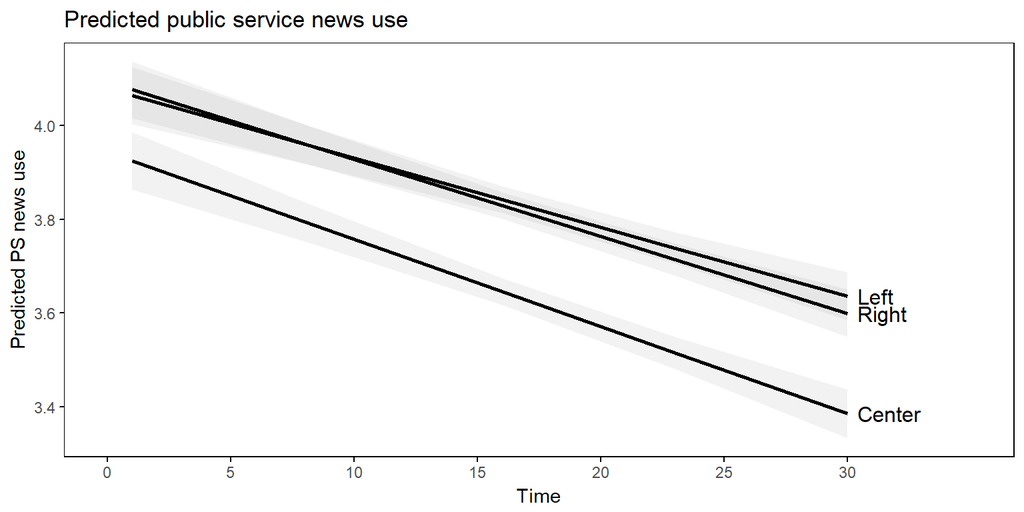

```r
# https://stackoverflow.com/questions/33763089/plotting-predicted-values-from-lmer-as-a-single-plot
Effect(c("time", "leaning"), mlm_interaction_leaning) %>%
  data.frame() %>%
  ggplot(aes(x=time, y=fit, fill=leaning, group=leaning)) +
  geom_line(size=1) +
  geom_ribbon(aes(ymin=lower, ymax=upper), alpha=0.05) +
  scale_x_continuous(labels=scales::comma, limit=c(0, 35), breaks=seq(0, 30, 5)) +
  scale_y_continuous(labels=scales::comma, breaks=seq(1, 6, 0.2) ) +
  scale_fill_manual("", values=c(1,1,1,1)) +
  scale_linetype_manual("", values=c(1,2,3,4)) +
  geom_dl(aes(label = leaning), method = list(dl.trans(x = x + .2), "last.points")) +
  theme(legend.position = "none", panel.grid = element_blank(), panel.border = element_rect(fill = "transparent"), axis.ticks.x = element_line(), axis.ticks.y = element_line()) +
  labs(title="Predicted public service news use",
       color="Leaning",
       linetype=NULL,
       x="Time",
       y="Predicted PS news use")
```

Plot time * party interaction. With controls.

- Remove Pirate Party (PP), Feminist Initiative (FI) and New Democracy (NyD) since they haven’t been along the whole period.
- Keep Sweden Democrats (SD), because they are in parliament later years + significant support among the citizens.

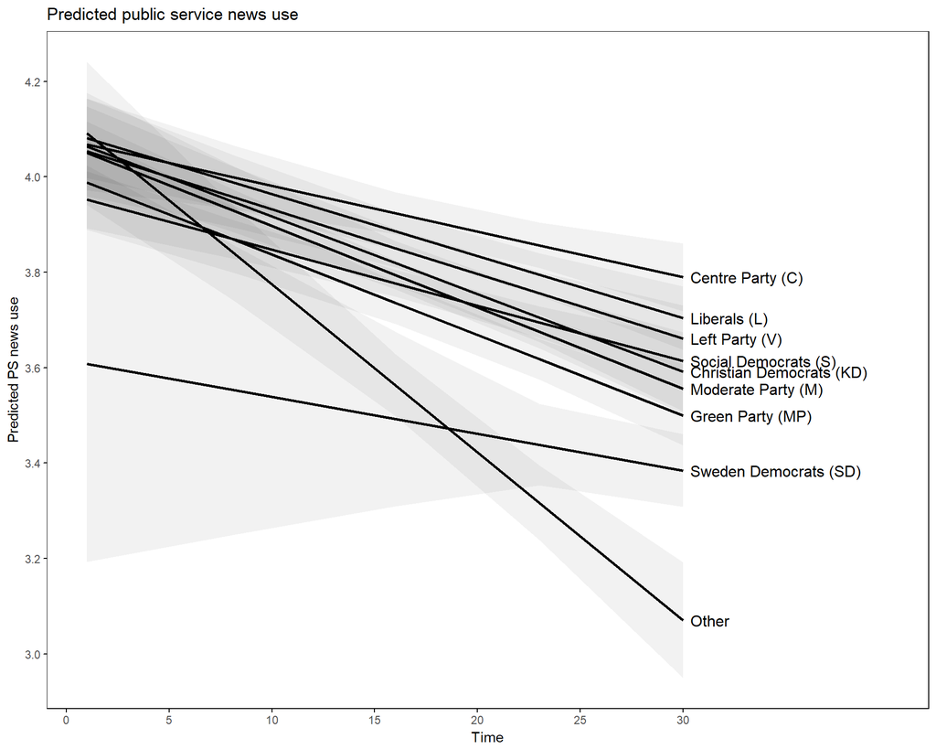

```r
Effect(c("time", "party"), mlm_interaction_party) %>%
  data.frame() %>%
  filter(!party %in% c("New Democracy (NyD)", "Pirate Party (PP)", "Feminist Initiative (FI)")) %>%
  ggplot(aes(x=time, y=fit, fill=party, group=party)) +
  geom_line(size=1) +
  geom_ribbon(aes(ymin=lower, ymax=upper), alpha=0.05) +
  scale_x_continuous(labels=scales::comma, limit=c(1, 40), breaks=seq(0, 30, 5) ) +
  scale_y_continuous(labels=scales::comma, breaks=seq(1, 6, 0.2) ) +
  scale_fill_manual("", values=c(rep(1, 12))) +
  scale_linetype_manual("", values=c(1,2,3,4)) +
  geom_dl(aes(label = party), method = list(dl.trans(x = x + .2), "last.points")) +
  theme(legend.position = "none", panel.grid = element_blank(), panel.border = element_rect(fill = "transparent"), axis.ticks.x = element_line(), axis.ticks.y = element_line()) +
  labs(title="Predicted public service news use",
       color="Political interest",
       linetype=NULL,
       x="Time",
       y="Predicted PS news use")
```

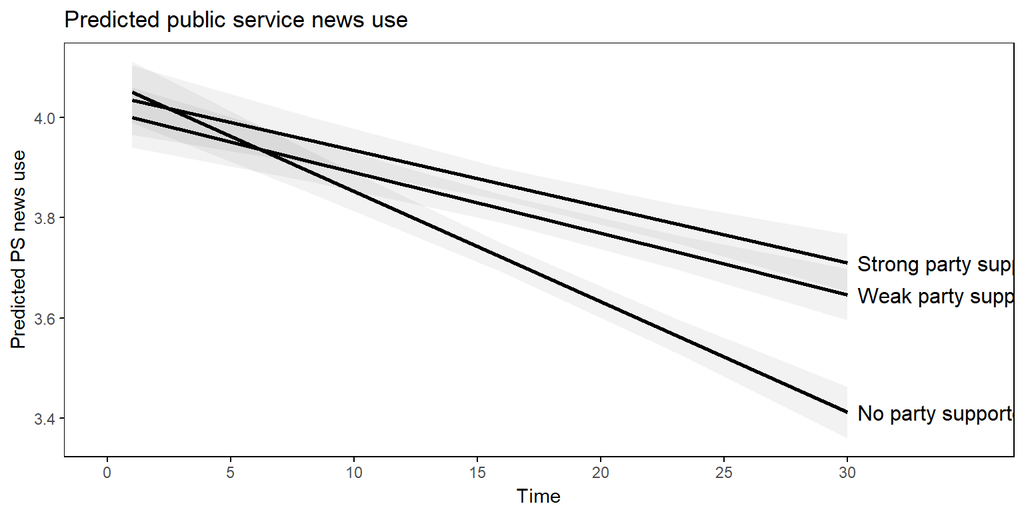

```r
Effect(c("time", "partystrength"), mlm_interaction_partystrength) %>%
  data.frame() %>%
  ggplot(aes(x=time, y=fit, fill=partystrength, group=partystrength)) +
  geom_line(size=1) +
  geom_ribbon(aes(ymin=lower, ymax=upper), alpha=0.05) +
  scale_x_continuous(labels=scales::comma, limit=c(0, 35), breaks=seq(0, 30, 5)) +
  scale_y_continuous(labels=scales::comma, breaks=seq(1, 6, 0.2) ) +
  scale_fill_manual("", values=c(1,1,1,1)) +
  scale_linetype_manual("", values=c(1,2,3,4)) +
  geom_dl(aes(label = partystrength), method = list(dl.trans(x = x + .2), "last.points")) +
  theme(legend.position = "none", panel.grid = element_blank(), panel.border = element_rect(fill = "transparent"), axis.ticks.x = element_line(), axis.ticks.y = element_line()) +
  labs(title="Predicted public service news use",
       color="Party Support",
       linetype=NULL,
       x="Time",
       y="Predicted PS news use")
```

Plot time * political interest interaction. With controls.

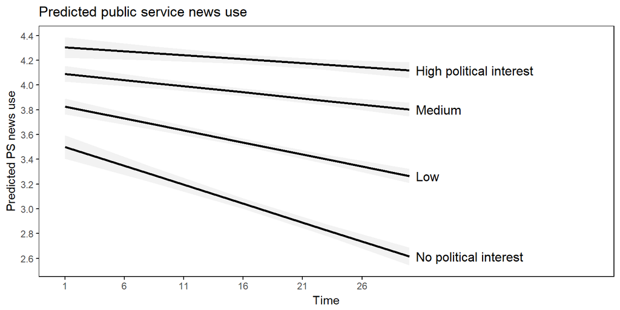

```r
Effect(c("time", "polinterest"), mlm_interaction_polint) %>%
  data.frame() %>%
  ggplot(aes(x=time, y=fit, fill=polinterest, group=polinterest)) +
  geom_line(size=1) +
  geom_ribbon(aes(ymin=lower, ymax=upper), alpha=0.05) +
  scale_x_continuous(labels=scales::comma, limit=c(1, 45), breaks=seq(1, 30, 5) ) +
  scale_y_continuous(labels=scales::comma, breaks=seq(1, 6, 0.2) ) +
  scale_fill_manual("", values=c(1,1,1,1)) +
  scale_linetype_manual("", values=c(1,2,3,4)) +
  geom_dl(aes(label = polinterest), method = list(dl.trans(x = x + .2), "last.points")) +
  theme(legend.position = "none", panel.grid = element_blank(), panel.border = element_rect(fill = "transparent"), axis.ticks.x = element_line(), axis.ticks.y = element_line()) +
  labs(title="Predicted public service news use",
       color="Political interest",
       linetype=NULL,
       x="Time",
       y="Predicted PS news use")
```